# Dissertation Analysis: Scores - Strategy

Jamiahus Walton

2019-05-31

# Q: Is there exciting variation among the *Score* metric that will help me understand the influence of the feedback condition?

## Team

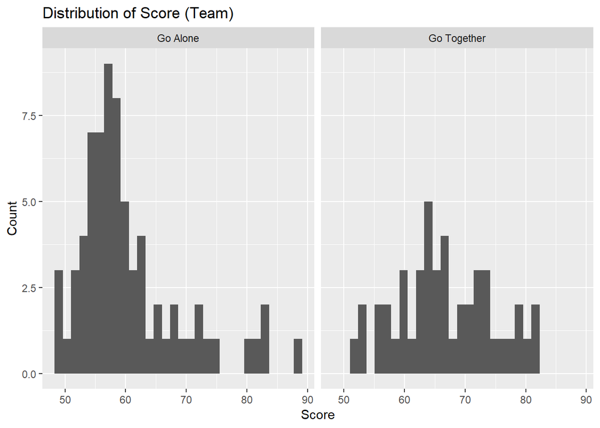

```r
y_label_team <- "Count"
x_label_team <- params$dependent_response_name_WithSpace
title_response_team <- paste("Distribution of", params$dependent_response_name_WithSpace, "(Team)")
plot_name <- paste("Histogram_", params$dependent_response_name_NoSpace, "_Team.png", sep = "")
setwd(figure_directory)

plot_data_team <- team_data %>%
  select(params$dependent_response_team,
         params$dependent_response_DominateStrategy,
         Target)

ggplot(data = plot_data_team) +
  geom_histogram(aes_string(x = params$dependent_response_team), bins = 30) +
  facet_grid( . ~ .data[[params$dependent_response_DominateStrategy]]) +
  labs(title = title_response_team, x = x_label_team, y = y_label_team) +
  ggsave(filename = plot_name)
```

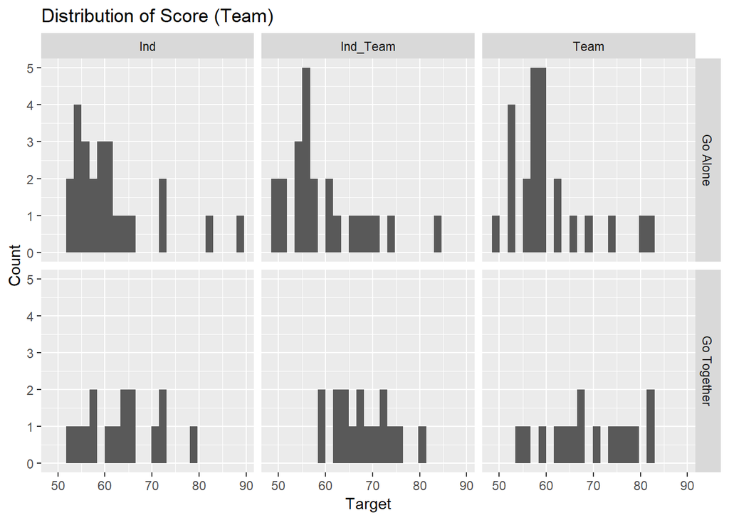

```r
y_label_team <- "Count"
x_label_team <- "Target"
title_response_team <- paste("Distribution of", params$dependent_response_name_WithSpace, "(Team)")
plot_name <- paste("Histogram_", params$dependent_response_name_NoSpace, "_ByTarget_Team.png", sep = "")
setwd(figure_directory)

plot_data_team <- team_data %>%
  select(params$dependent_response_team,
         params$dependent_response_DominateStrategy,
         Target)

ggplot(data = plot_data_team) +
  geom_histogram(aes_string(x = params$dependent_response_team), bins = 25) +
  facet_grid(.data[[params$dependent_response_DominateStrategy]] ~ Target) +
  labs(title = title_response_team, x = x_label_team, y = y_label_team) +
  ggsave(filename = plot_name)
```

```r
# Information about the N values in each condition
tableData <- team_data %>%
  group_by(Target, .data[[params$dependent_response_DominateStrategy]]) %>%
  summarise(N = length(.data[[params$dependent_response_team]]))

tableData %>%
  kable() %>%
  kable_styling()
```

| Target | Dominate.Strategy | N |
| --- | --- | --- |
| Ind | Go Alone | 24 |
| Ind | Go Together | 15 |
| Ind_Team | Go Alone | 23 |
| Ind_Team | Go Together | 16 |
| Team | Go Alone | 24 |
| Team | Go Together | 15 |

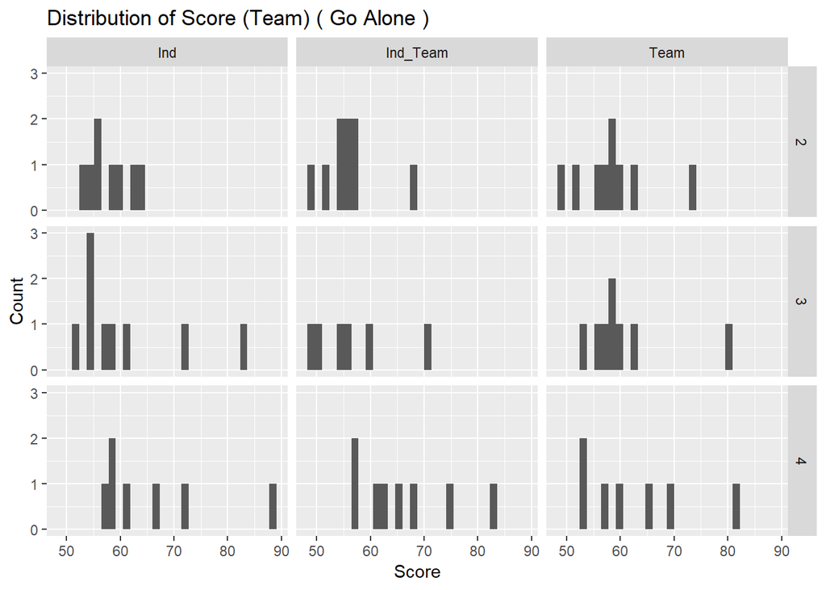

```r
y_label_team <- "Count"
x_label_team <- params$dependent_response_name_WithSpace
setwd(figure_directory)

plot_data_team <- team_data %>%
  select(params$dependent_response_team,
         params$dependent_response_DominateStrategy,
         Target,
         SessionOrder)

# Generate data by strategy
GA_plot_data_team <- plot_data_team %>%
  filter(.data[[params$dependent_response_DominateStrategy]] == params$Strategy_GA_name_WithSpace)

GT_plot_data_team <- plot_data_team %>%
  filter(.data[[params$dependent_response_DominateStrategy]] == params$Strategy_GT_name_WithSpace)

# Plot
 # GA
ggplot(data = GA_plot_data_team) +
  geom_histogram(aes_string(x = params$dependent_response_team), bins = 30) +
  labs(title = paste("Distribution of", params$dependent_response_name_WithSpace, "(Team)","(", params$Strategy_GA_name_WithSpace ,")" ), x = x_label_team, y = y_label_team) +
  facet_grid( SessionOrder ~ Target) +
  ggsave(filename = paste("Histogram_", params$dependent_response_name_NoSpace, "_ByTarget_BySessionOrder_", params$Strategy_GA_name_NoSpace, "_Team.png", sep = ""))
```

```r
    # Information about the N values in each condition
GA_tableData <- GA_plot_data_team %>%
  select(params$dependent_response_team, Target, SessionOrder) %>%
  group_by(Target, SessionOrder) %>%
  summarise(N = length(.data[[params$dependent_response_team]]))

GA_tableData %>%
  kable(caption = paste("Data for ", params$Strategy_GA_name_WithSpace)) %>%
  kable_styling()
```

Data for Go Alone

| Target | SessionOrder | N |
| --- | --- | --- |
| Ind | 2 | 8 |
| Ind | 3 | 9 |
| Ind | 4 | 7 |
| Ind_Team | 2 | 9 |
| Ind_Team | 3 | 6 |
| Ind_Team | 4 | 8 |
| Team | 2 | 9 |
| Team | 3 | 8 |
| Team | 4 | 7 |

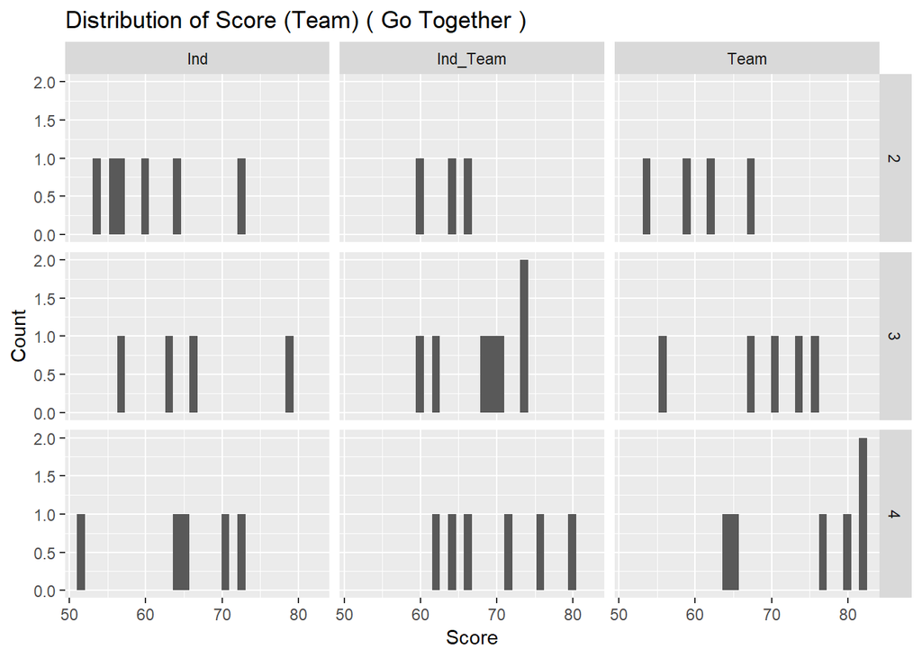

```r
 # GT
ggplot(data = GT_plot_data_team) +
  geom_histogram(aes_string(x = params$dependent_response_team), bins = 30) +
  labs(title = paste("Distribution of", params$dependent_response_name_WithSpace, "(Team)","(", params$Strategy_GT_name_WithSpace ,")" ), x = x_label_team, y = y_label_team) +
  facet_grid( SessionOrder ~ Target) +
  ggsave(filename = paste("Histogram_", params$dependent_response_name_NoSpace, "_ByTarget_BySessionOrder_", params$Strategy_GT_name_NoSpace, "_Team.png", sep = ""))
```

```r
    # Information about the N values in each condition
GT_tableData <- GT_plot_data_team %>%
  select(params$dependent_response_team, Target, SessionOrder) %>%
  group_by(Target, SessionOrder) %>%
  summarise(N = length(.data[[params$dependent_response_team]]))

GT_tableData %>%
  kable(caption = paste("Data for ", params$Strategy_GT_name_WithSpace)) %>%
  kable_styling()
```

Data for Go Together

| Target | SessionOrder | N |
| --- | --- | --- |
| Ind | 2 | 6 |
| Ind | 3 | 4 |
| Ind | 4 | 5 |
| Ind_Team | 2 | 3 |
| Ind_Team | 3 | 7 |
| Ind_Team | 4 | 6 |
| Team | 2 | 4 |
| Team | 3 | 5 |
| Team | 4 | 6 |

In the Go Alone, the distributions starts out as normal but then flattens over time. In the Go Together, the distributions seems to be flat over time but shift to the right over time as well.

## Individual

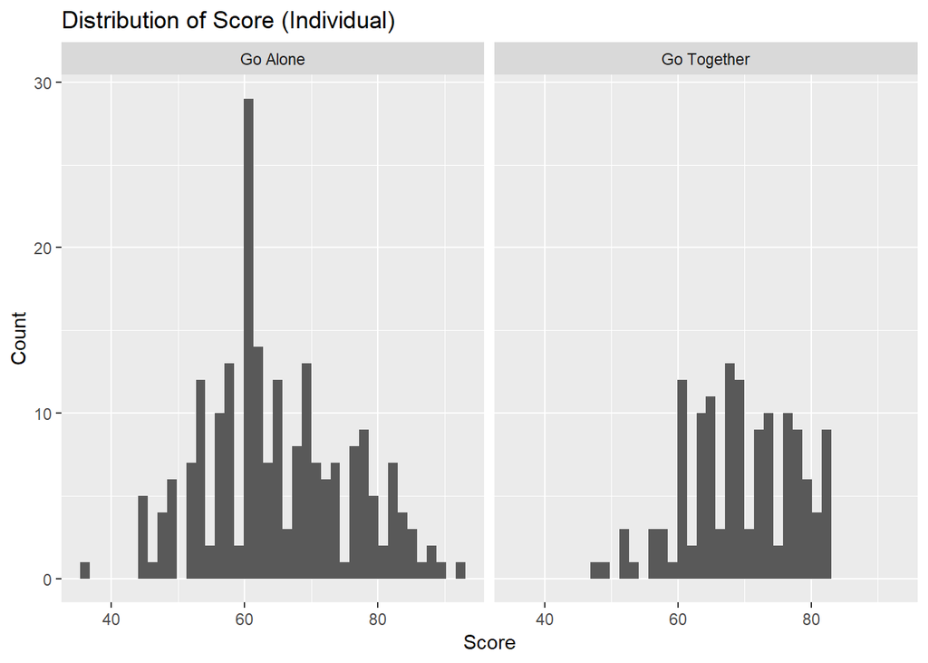

```r
y_label_ind <- "Count"
x_label_ind <- params$dependent_response_name_WithSpace
title_response_ind <- paste("Distribution of", params$dependent_response_name_WithSpace, "(Individual)")
plot_name <- paste("Histogram_", params$dependent_response_name_NoSpace, "_Ind.png", sep = "")
setwd(figure_directory)

plot_data_ind <- ind_data %>%
  select(params$dependent_response_ind, params$dependent_response_DominateStrategy, Target)

ggplot(data = plot_data_ind) +
  geom_histogram(aes_string(x = params$dependent_response_ind), bins = 40) +
  facet_grid(. ~ .data[[params$dependent_response_DominateStrategy]]) +
  labs(title = title_response_ind, x = x_label_ind, y = y_label_ind) +
  ggsave(filename = plot_name)
```

The distribution in the both groups seem to be normally distributed. However, the center in the Go Alone is around ~61 and the the center in the Go Together is around ~68, indicating the individual scores are higher in the Go Together.

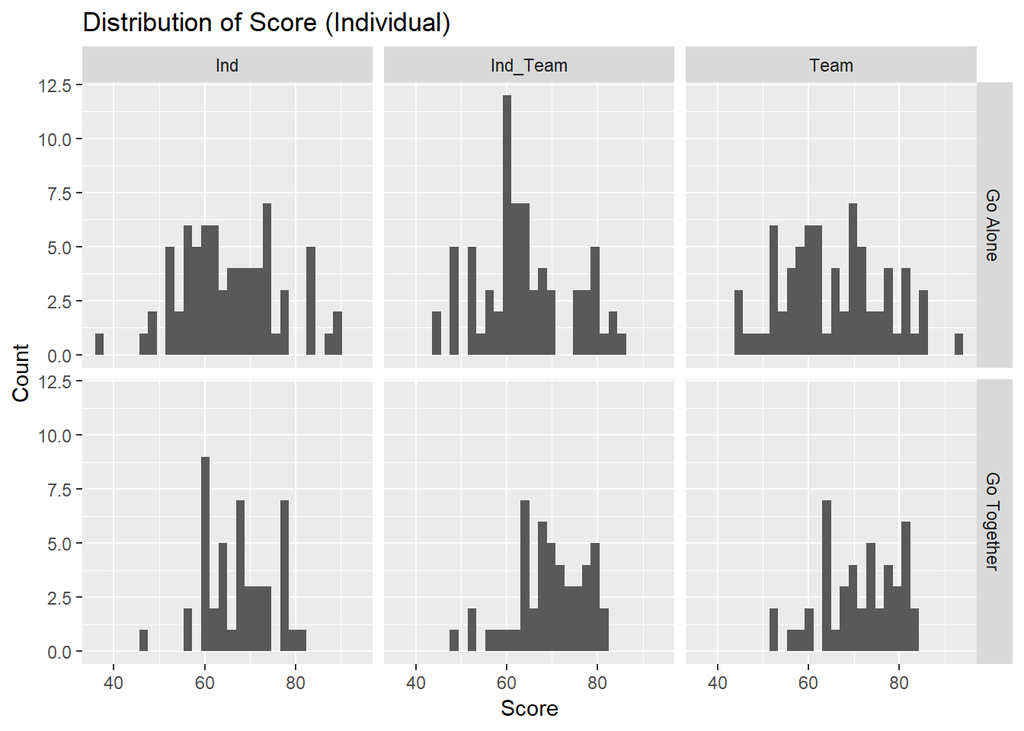

```r
y_label_ind <- "Count"
x_label_ind <- params$dependent_response_name_WithSpace
title_response_ind <- paste("Distribution of", params$dependent_response_name_WithSpace, "(Individual)")
plot_name <- paste("Histogram_", params$dependent_response_name_NoSpace, "_ByTarget_Ind.png", sep = "")
setwd(figure_directory)

plot_data_ind <- ind_data %>%
  select(params$dependent_response_ind, params$dependent_response_DominateStrategy, Target)

ggplot(data = plot_data_ind) +
  geom_histogram(aes_string(x = params$dependent_response_ind), bins = 30) +
  facet_grid(.data[[params$dependent_response_DominateStrategy]] ~ Target) +
  labs(title = title_response_ind, x = x_label_ind, y = y_label_ind) +
  ggsave(filename = plot_name)
```

```r
# Information about the N values in each condition
tableData <- ind_data %>%
  group_by(Target, .data[[params$dependent_response_DominateStrategy]]) %>%
  summarise(N = length(.data[[params$dependent_response_ind]]))

tableData %>%
  kable() %>%
  kable_styling()
```

| Target | Dominate.Strategy | N |
| --- | --- | --- |
| Ind | Go Alone | 72 |
| Ind | Go Together | 45 |
| Ind_Team | Go Alone | 69 |
| Ind_Team | Go Together | 48 |
| Team | Go Alone | 72 |
| Team | Go Together | 45 |

In both the Go Alone group and the Go Together, the distribution appears to be similar to their repsective overall distribution.

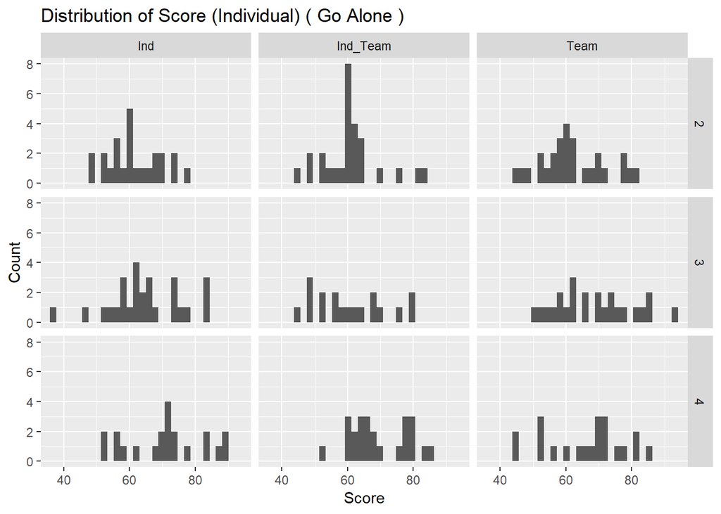

```r
y_label_ind <- "Count"
x_label_ind <- params$dependent_response_name_WithSpace
setwd(figure_directory)

plot_data_ind <- ind_data %>%
  select(params$dependent_response_ind,
         params$dependent_response_DominateStrategy,
         Target,
         SessionOrder)

# Generate data by strategy
GA_plot_data_ind <- plot_data_ind %>%
  filter(.data[[params$dependent_response_DominateStrategy]] == params$Strategy_GA_name_WithSpace)

GT_plot_data_ind <- plot_data_ind %>%
  filter(.data[[params$dependent_response_DominateStrategy]] == params$Strategy_GT_name_WithSpace)

# plot
  # GA
ggplot(data = GA_plot_data_ind) +
  geom_histogram(aes_string(x = params$dependent_response_ind), bins = 30) +
  facet_grid(SessionOrder ~ Target) +
  labs(title = paste("Distribution of", params$dependent_response_name_WithSpace, "(Individual)","(", params$Strategy_GA_name_WithSpace ,")" ), x = x_label_ind, y = y_label_ind) +
  ggsave(filename = paste("Histogram_", params$dependent_response_name_NoSpace, "_ByTarget_BySessionOrder_", params$Strategy_GA_name_NoSpace, "_Ind.png", sep = ""))
```

```r
    # Information about the N values in each condition
GA_tableData <- GA_plot_data_ind %>%
  select(params$dependent_response_ind, Target, SessionOrder) %>%
  group_by(Target, SessionOrder) %>%
  summarise(N = length(.data[[params$dependent_response_ind]]))

GA_tableData %>%
  kable(caption =  paste("Data for ", params$Strategy_GA_name_WithSpace)) %>%
  kable_styling()
```

Data for Go Alone

| Target | SessionOrder | N |
| --- | --- | --- |
| Ind | 2 | 24 |
| Ind | 3 | 27 |
| Ind | 4 | 21 |
| Ind_Team | 2 | 27 |
| Ind_Team | 3 | 18 |
| Ind_Team | 4 | 24 |
| Team | 2 | 27 |
| Team | 3 | 24 |
| Team | 4 | 21 |

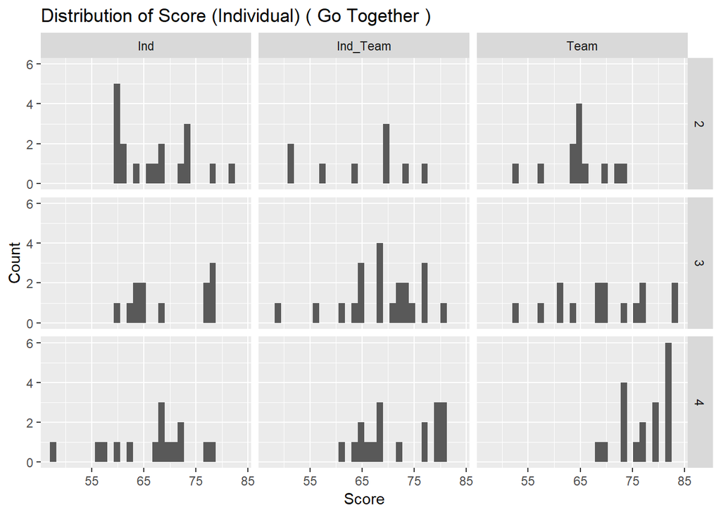

```r
  # GT
ggplot(data = GT_plot_data_ind) +
  geom_histogram(aes_string(x = params$dependent_response_ind), bins = 30) +
  facet_grid(SessionOrder ~ Target) +
  labs(title = paste("Distribution of", params$dependent_response_name_WithSpace, "(Individual)","(", params$Strategy_GT_name_WithSpace ,")" ), x = x_label_ind, y = y_label_ind) +
  ggsave(filename = paste("Histogram_", params$dependent_response_name_NoSpace, "_ByTarget_BySessionOrder_", params$Strategy_GT_name_NoSpace, "_Ind.png", sep = ""))
```

```r
# Information about the N values in each condition
GT_tableData <- GT_plot_data_ind %>%
  select(params$dependent_response_ind, Target, SessionOrder) %>%
  group_by(Target, SessionOrder) %>%
  summarise(N = length(.data[[params$dependent_response_ind]]))

GT_tableData %>%
  kable(caption = paste("Data for ", params$Strategy_GT_name_WithSpace)) %>%
  kable_styling()
```

Data for Go Together

| Target | SessionOrder | N |
| --- | --- | --- |
| Ind | 2 | 18 |
| Ind | 3 | 12 |
| Ind | 4 | 15 |
| Ind_Team | 2 | 9 |
| Ind_Team | 3 | 21 |
| Ind_Team | 4 | 18 |
| Team | 2 | 12 |
| Team | 3 | 15 |
| Team | 4 | 18 |

In the Go Alone group, the distribution of the scores flatten over time.

In the Go Together, the distribution of the scores in the Ind and Ind_Team condition flatten over time. In the Team condition, the scores seem to skew to the right over time.

## Summary

Overall, it seems as though there is something interesting occuring when grouping the data by strategy.

# Q: Is there an interaction between the Target and Session Order for the *Score* that is statistically significant?

I am interested in determining if a linear mixed effect model should include the interaction effect between the Target and Session Order variable.

A note on the effect size ($R^2$). This method generates two types of ($R^2$) values called marginal ($R_{m}^2$) and conditional ($R_{c}^2$) effect size. The $R_{m}^2$ calculates how much of the variance is described by the fixed effect variables (feedback condition and session order) while the $R_{c}^2$ calculates how much of the variance is described by both the fixed and random effect variables.

## Full Models Used for Team and Individual

The next two sections below describe the full model for team and individual level analysis. Five models were fitted and then compared. One model was the null model, one model was the full model, and the last three are a subset of the full model.

### Team Full Model

$$y_{ijt} = \mu + \alpha_{i} + \beta_{j} + \alpha_{i} \beta_{j} + \gamma_{t} + \epsilon_{ijt}$$

### Individual Team Full Model

$$y_{ijtp} = \mu + \alpha_{i} + \beta_{j} + \alpha_{i} \beta_{j} + \gamma_{t} + \theta_{p} + \epsilon_{ijtp}$$

## Team

### *Go Alone*

```r
# Data to fit
data_modified_team <- team_data %>%
  select(TeamScore,
         params$dependent_response_team,
         params$dependent_response_DominateStrategy,
         Target,
         SessionOrder,
         Team)

# Generate models with variable response
GA_data_focus_team <- data_modified_team %>%
  filter(.data[[params$dependent_response_DominateStrategy]] == params$Strategy_GA_name_WithSpace)

model.null <- model_data_Target_Session(df = GA_data_focus_team, dependent =  params$dependent_response_team, model.type =  "null", is.team = TRUE, is.robust =FALSE)
model.All <- model_data_Target_Session(df = GA_data_focus_team, dependent =  params$dependent_response_team, model.type =  "All", is.team = TRUE, is.robust = FALSE)
model.NoInteraction <- model_data_Target_Session(df = GA_data_focus_team, dependent =  params$dependent_response_team, model.type =  "NoInteraction", is.team = TRUE, is.robust = FALSE)
model.NoInteraction.NoTarget <- model_data_Target_Session(df = GA_data_focus_team, dependent =  params$dependent_response_team, model.type =  "NoInteraction_NoTarget", is.team = TRUE, is.robust = FALSE)
model.NoInteraction.NoSession <- model_data_Target_Session(df = GA_data_focus_team, dependent =  params$dependent_response_team, model.type =  "NoInteraction_NoSession", is.team = TRUE, is.robust = FALSE)

# There is an option to compare all the models with the anova(). However, the function does not compare all models to model.null
anova(model.null,
      model.All) %>%
  kable(caption = "ANOVA: Null and All") %>%
  kable_styling()
```

```
## refitting model(s) with ML (instead of REML)
```

ANOVA: Null and All

|  | Df | AIC | BIC | logLik | deviance | Chisq | Chi Df | Pr(>Chisq) |
| --- | --- | --- | --- | --- | --- | --- | --- | --- |
| model.null | 3 | 496.9576 | 503.7456 | -245.4788 | 490.9576 | NA | NA | NA |
| model.All | 11 | 487.9553 | 512.8448 | -232.9776 | 465.9553 | 25.00229 | 8 | 0.0015532 |

```r
anova(model.null,
      model.NoInteraction) %>%
  kable(caption = "ANOVA: Null and No.Interaction") %>%
  kable_styling()
```

```
## refitting model(s) with ML (instead of REML)
```

ANOVA: Null and No.Interaction

|  | Df | AIC | BIC | logLik | deviance | Chisq | Chi Df | Pr(>Chisq) |
| --- | --- | --- | --- | --- | --- | --- | --- | --- |
| model.null | 3 | 496.9576 | 503.7456 | -245.4788 | 490.9576 | NA | NA | NA |
| model.NoInteraction | 7 | 482.5962 | 498.4349 | -234.2981 | 468.5962 | 22.36139 | 4 | 0.0001698 |

```r
anova(model.null,
      model.NoInteraction.NoTarget) %>%
  kable(caption = "ANOVA: Null and No.Interaction.No.Target") %>%
  kable_styling()
```

```
## refitting model(s) with ML (instead of REML)
```

ANOVA: Null and No.Interaction.No.Target

|  | Df | AIC | BIC | logLik | deviance | Chisq | Chi Df | Pr(>Chisq) |
| --- | --- | --- | --- | --- | --- | --- | --- | --- |
| model.null | 3 | 496.9576 | 503.7456 | -245.4788 | 490.9576 | NA | NA | NA |
| model.NoInteraction.NoTarget | 5 | 479.7978 | 491.1112 | -234.8989 | 469.7978 | 21.1598 | 2 | 2.54e-05 |

```r
anova(model.null,
      model.NoInteraction.NoSession) %>%
  kable(caption = "ANOVA: Null and No.Interaction.No.Session") %>%
  kable_styling()
```

```
## refitting model(s) with ML (instead of REML)
```

ANOVA: Null and No.Interaction.No.Session

|  | Df | AIC | BIC | logLik | deviance | Chisq | Chi Df | Pr(>Chisq) |
| --- | --- | --- | --- | --- | --- | --- | --- | --- |
| model.null | 3 | 496.9576 | 503.7456 | -245.4788 | 490.9576 | NA | NA | NA |
| model.NoInteraction.NoSession | 5 | 500.2272 | 511.5406 | -245.1136 | 490.2272 | 0.7303575 | 2 | 0.6940726 |

The following models were significantly different from the null model: model.All, model.NoInteraction, model.NoInteraction.NoTarget.

model.All: Session Order, Target, and the interaction are included in this model.

model.NoInteraction: Session order and target are the fixed effects in this model.

model.NoInteraction.NoTarget: Session order is the only fixed effect in this model.

```r
# Data to fit
data_modified_team <- team_data %>%
  select(TeamScore,
         params$dependent_response_team,
         params$dependent_response_DominateStrategy,
         Target,
         SessionOrder,
         Team)

# Generate models with variable response
GA_data_focus_team <- data_modified_team %>%
  filter(.data[[params$dependent_response_DominateStrategy]] == params$Strategy_GA_name_WithSpace)

model.All <- model_data_Target_Session(df = GA_data_focus_team, dependent =  params$dependent_response_team, model.type =  "All", is.team = TRUE, is.robust = FALSE)
model.NoInteraction <- model_data_Target_Session(df = GA_data_focus_team, dependent =  params$dependent_response_team, model.type =  "NoInteraction", is.team = TRUE, is.robust = FALSE)
model.NoInteraction.NoTarget <- model_data_Target_Session(df = GA_data_focus_team, dependent =  params$dependent_response_team, model.type =  "NoInteraction_NoTarget", is.team = TRUE, is.robust = FALSE)

# Compare all of the models
anova(model.All,
      model.NoInteraction) %>%
  kable(caption = "ANOVA: model.All and model.NoInteraction") %>%
  kable_styling()
```

```
## refitting model(s) with ML (instead of REML)
```

ANOVA: model.All and model.NoInteraction

|  | Df | AIC | BIC | logLik | deviance | Chisq | Chi Df | Pr(>Chisq) |
| --- | --- | --- | --- | --- | --- | --- | --- | --- |
| model.NoInteraction | 7 | 482.5962 | 498.4349 | -234.2981 | 468.5962 | NA | NA | NA |
| model.All | 11 | 487.9553 | 512.8448 | -232.9776 | 465.9553 | 2.640906 | 4 | 0.6195942 |

```r
anova(model.All,
      model.NoInteraction.NoTarget) %>%
  kable(caption = "ANOVA: model.All and model.NoInteraction.NoTarget") %>%
  kable_styling()
```

```
## refitting model(s) with ML (instead of REML)
```

ANOVA: model.All and model.NoInteraction.NoTarget

|  | Df | AIC | BIC | logLik | deviance | Chisq | Chi Df | Pr(>Chisq) |
| --- | --- | --- | --- | --- | --- | --- | --- | --- |
| model.NoInteraction.NoTarget | 5 | 479.7978 | 491.1112 | -234.8989 | 469.7978 | NA | NA | NA |
| model.All | 11 | 487.9553 | 512.8448 | -232.9776 | 465.9553 | 3.842488 | 6 | 0.697982 |

```r
anova(model.NoInteraction,
      model.NoInteraction.NoTarget) %>%
  kable(caption = "ANOVA: model.NoInteraction and model.NoInteraction.NoTarget") %>%
  kable_styling()
```

```
## refitting model(s) with ML (instead of REML)
```

ANOVA: model.NoInteraction and model.NoInteraction.NoTarget

|  | Df | AIC | BIC | logLik | deviance | Chisq | Chi Df | Pr(>Chisq) |
| --- | --- | --- | --- | --- | --- | --- | --- | --- |
| model.NoInteraction.NoTarget | 5 | 479.7978 | 491.1112 | -234.8989 | 469.7978 | NA | NA | NA |
| model.NoInteraction | 7 | 482.5962 | 498.4349 | -234.2981 | 468.5962 | 1.201583 | 2 | 0.5483775 |

Overall, model.All is not signifcantly different from model.NoInteraction.NoTarget or model.NoInteraction, indicating that the interaction effect can be ignored. The model model.NoInteraction is not significantly different from model.NoInteraction.NoTarget. However, the AIC and the BIC values are very similar.

```r
# Data to fit
data_modified_team <- team_data %>%
  select(TeamScore,
         params$dependent_response_team,
         params$dependent_response_DominateStrategy,
         Target,
         SessionOrder,
         Team)

# Generate models with variable response
GA_data_focus_team <- data_modified_team %>%
  filter(.data[[params$dependent_response_DominateStrategy]] == params$Strategy_GA_name_WithSpace)

model.NoInteraction <- model_data_Target_Session(df = GA_data_focus_team, dependent =  params$dependent_response_team, model.type =  "NoInteraction", is.team = TRUE, is.robust = FALSE)
model.NoInteraction.NoTarget <- model_data_Target_Session(df = GA_data_focus_team, dependent =  params$dependent_response_team, model.type =  "NoInteraction_NoTarget", is.team = TRUE, is.robust = FALSE)

# Effect size (R^2)

r.squaredGLMM(model.NoInteraction.NoTarget) %>%
  kable(caption = "Table: Effect size for *No Interaction and No Target*") %>%
   kable_styling(full_width = F)
```

Table: Effect size for *No Interaction and No Target*

| R2m | R2c |
| --- | --- |
| 0.1336864 | 0.6500498 |

```r
r.squaredGLMM(model.NoInteraction) %>%
  kable(caption = "Table: Effect size for *No Interaction*") %>%
   kable_styling(full_width = F)
```

Table: Effect size for *No Interaction*

| R2m | R2c |
| --- | --- |
| 0.1373824 | 0.6446308 |

I see no noticeable difference. The rule of thumb is to use the simplest model to represent the data. However, in this analysis I will examine **model.NoInteraction.NoTarget** and **model.NoInteraction** because the AIC and BIC values are close and the effect sizes are close.

### *Go Together*

```r
# Data to fit
data_modified_team <- team_data %>%
  select(TeamScore,
         params$dependent_response_team,
         params$dependent_response_DominateStrategy,
         Target,
         SessionOrder,
         Team)

# Generate models with variable response
GT_data_focus_team <- data_modified_team %>%
  filter(.data[[params$dependent_response_DominateStrategy]] == params$Strategy_GT_name_WithSpace)

model.null <- model_data_Target_Session(df = GT_data_focus_team, dependent =  params$dependent_response_team, model.type =  "null", is.team = TRUE, is.robust =FALSE)
model.All <- model_data_Target_Session(df = GT_data_focus_team, dependent =  params$dependent_response_team, model.type =  "All", is.team = TRUE, is.robust = FALSE)
model.NoInteraction <- model_data_Target_Session(df = GT_data_focus_team, dependent =  params$dependent_response_team, model.type =  "NoInteraction", is.team = TRUE, is.robust = FALSE)
model.NoInteraction.NoTarget <- model_data_Target_Session(df = GT_data_focus_team, dependent =  params$dependent_response_team, model.type =  "NoInteraction_NoTarget", is.team = TRUE, is.robust = FALSE)
model.NoInteraction.NoSession <- model_data_Target_Session(df = GT_data_focus_team, dependent =  params$dependent_response_team, model.type =  "NoInteraction_NoSession", is.team = TRUE, is.robust = FALSE)

# There is an option to compare all the models with the anova(). However, the function does not compare all models to model.null
anova(model.null,
      model.All) %>%
  kable(caption = "ANOVA: Null and All") %>%
  kable_styling()
```

```
## refitting model(s) with ML (instead of REML)
```

ANOVA: Null and All

|  | Df | AIC | BIC | logLik | deviance | Chisq | Chi Df | Pr(>Chisq) |
| --- | --- | --- | --- | --- | --- | --- | --- | --- |
| model.null | 3 | 324.7759 | 330.2618 | -159.3880 | 318.7759 | NA | NA | NA |
| model.All | 11 | 316.7004 | 336.8155 | -147.3502 | 294.7004 | 24.0755 | 8 | 0.0022259 |

```r
anova(model.null,
      model.NoInteraction) %>%
  kable(caption = "ANOVA: Null and No.Interaction") %>%
  kable_styling()
```

```
## refitting model(s) with ML (instead of REML)
```

ANOVA: Null and No.Interaction

|  | Df | AIC | BIC | logLik | deviance | Chisq | Chi Df | Pr(>Chisq) |
| --- | --- | --- | --- | --- | --- | --- | --- | --- |
| model.null | 3 | 324.7759 | 330.2618 | -159.3880 | 318.7759 | NA | NA | NA |
| model.NoInteraction | 7 | 310.5846 | 323.3851 | -148.2923 | 296.5846 | 22.19129 | 4 | 0.0001836 |

```r
anova(model.null,
      model.NoInteraction.NoTarget) %>%
  kable(caption = "ANOVA: Null and No.Interaction.No.Target") %>%
  kable_styling()
```

```
## refitting model(s) with ML (instead of REML)
```

ANOVA: Null and No.Interaction.No.Target

|  | Df | AIC | BIC | logLik | deviance | Chisq | Chi Df | Pr(>Chisq) |
| --- | --- | --- | --- | --- | --- | --- | --- | --- |
| model.null | 3 | 324.7759 | 330.2618 | -159.3880 | 318.7759 | NA | NA | NA |
| model.NoInteraction.NoTarget | 5 | 310.0006 | 319.1438 | -150.0003 | 300.0006 | 18.7753 | 2 | 8.38e-05 |

```r
anova(model.null,
      model.NoInteraction.NoSession) %>%
  kable(caption = "ANOVA: Null and No.Interaction.No.Session") %>%
  kable_styling()
```

```
## refitting model(s) with ML (instead of REML)
```

ANOVA: Null and No.Interaction.No.Session

|  | Df | AIC | BIC | logLik | deviance | Chisq | Chi Df | Pr(>Chisq) |
| --- | --- | --- | --- | --- | --- | --- | --- | --- |
| model.null | 3 | 324.7759 | 330.2618 | -159.3880 | 318.7759 | NA | NA | NA |
| model.NoInteraction.NoSession | 5 | 324.2334 | 333.3766 | -157.1167 | 314.2334 | 4.542489 | 2 | 0.1031837 |

The following models were significantly different from the null model: model.All, model.NoInteraction, model.NoInteraction.NoTarget.

model.All: Session Order, Target, and the interaction are included in this model.

model.NoInteraction: Session order and target are the fixed effects in this model.

model.NoInteraction.NoTarget: Session order is the only fixed effect in this model.

```r
# Data to fit
data_modified_team <- team_data %>%
  select(TeamScore,
         params$dependent_response_team,
         params$dependent_response_DominateStrategy,
         Target,
         SessionOrder,
         Team)

# Generate models with variable response
GT_data_focus_team <- data_modified_team %>%
  filter(.data[[params$dependent_response_DominateStrategy]] == params$Strategy_GT_name_WithSpace)

model.All <- model_data_Target_Session(df = GT_data_focus_team, dependent =  params$dependent_response_team, model.type =  "All", is.team = TRUE, is.robust = FALSE)
model.NoInteraction <- model_data_Target_Session(df = GT_data_focus_team, dependent =  params$dependent_response_team, model.type =  "NoInteraction", is.team = TRUE, is.robust = FALSE)
model.NoInteraction.NoTarget <- model_data_Target_Session(df = GT_data_focus_team, dependent =  params$dependent_response_team, model.type =  "NoInteraction_NoTarget", is.team = TRUE, is.robust = FALSE)

# Compare all of the models
anova(model.All,
      model.NoInteraction) %>%
  kable(caption = "ANOVA: model.All and model.NoInteraction") %>%
  kable_styling()
```

```
## refitting model(s) with ML (instead of REML)
```

ANOVA: model.All and model.NoInteraction

|  | Df | AIC | BIC | logLik | deviance | Chisq | Chi Df | Pr(>Chisq) |
| --- | --- | --- | --- | --- | --- | --- | --- | --- |
| model.NoInteraction | 7 | 310.5846 | 323.3851 | -148.2923 | 296.5846 | NA | NA | NA |
| model.All | 11 | 316.7004 | 336.8155 | -147.3502 | 294.7004 | 1.884211 | 4 | 0.7570449 |

```r
anova(model.All,
      model.NoInteraction.NoTarget) %>%
  kable(caption = "ANOVA: model.All and model.NoInteraction.NoTarget") %>%
  kable_styling()
```

```
## refitting model(s) with ML (instead of REML)
```

ANOVA: model.All and model.NoInteraction.NoTarget

|  | Df | AIC | BIC | logLik | deviance | Chisq | Chi Df | Pr(>Chisq) |
| --- | --- | --- | --- | --- | --- | --- | --- | --- |
| model.NoInteraction.NoTarget | 5 | 310.0006 | 319.1438 | -150.0003 | 300.0006 | NA | NA | NA |
| model.All | 11 | 316.7004 | 336.8155 | -147.3502 | 294.7004 | 5.300201 | 6 | 0.5059261 |

```r
anova(model.NoInteraction,
      model.NoInteraction.NoTarget) %>%
  kable(caption = "ANOVA: model.NoInteraction and model.NoInteraction.NoTarget") %>%
  kable_styling()
```

```
## refitting model(s) with ML (instead of REML)
```

ANOVA: model.NoInteraction and model.NoInteraction.NoTarget

|  | Df | AIC | BIC | logLik | deviance | Chisq | Chi Df | Pr(>Chisq) |
| --- | --- | --- | --- | --- | --- | --- | --- | --- |
| model.NoInteraction.NoTarget | 5 | 310.0006 | 319.1438 | -150.0003 | 300.0006 | NA | NA | NA |
| model.NoInteraction | 7 | 310.5846 | 323.3851 | -148.2923 | 296.5846 | 3.415991 | 2 | 0.1812287 |

Overall, model.All is not signifcantly different from model.NoInteraction.NoTarget or model.NoInteraction, indicating that the interaction effect can be ignored. The model model.NoInteraction is not significantly different from model.NoInteraction.NoTarget. However, the AIC and the BIC values are very similar.

```r
# Data to fit
data_modified_team <- team_data %>%
  select(TeamScore,
         params$dependent_response_team,
         params$dependent_response_DominateStrategy,
         Target,
         SessionOrder,
         Team)

# Generate models with variable response
GT_data_focus_team <- data_modified_team %>%
  filter(.data[[params$dependent_response_DominateStrategy]] == params$Strategy_GT_name_WithSpace)

model.NoInteraction <- model_data_Target_Session(df = GT_data_focus_team, dependent =  params$dependent_response_team, model.type =  "NoInteraction", is.team = TRUE, is.robust = FALSE)
model.NoInteraction.NoTarget <- model_data_Target_Session(df = GT_data_focus_team, dependent =  params$dependent_response_team, model.type =  "NoInteraction_NoTarget", is.team = TRUE, is.robust = FALSE)

# Effect size (R^2)

r.squaredGLMM(model.NoInteraction.NoTarget) %>%
  kable(caption = "Table: Effect size for *No Interaction and No Target*") %>%
   kable_styling(full_width = F)
```

Table: Effect size for *No Interaction and No Target*

| R2m | R2c |
| --- | --- |
| 0.234742 | 0.6436336 |

```r
r.squaredGLMM(model.NoInteraction) %>%
  kable(caption = "Table: Effect size for *No Interaction*") %>%
   kable_styling(full_width = F)
```

Table: Effect size for *No Interaction*

| R2m | R2c |
| --- | --- |
| 0.2604378 | 0.629069 |

I see no noticeable difference. The rule of thumb is to use the simplest model to represent the data. However, in this analysis I will examine **model.NoInteraction.NoTarget** and **model.NoInteraction** because the AIC and BIC values are close and the effect sizes are close.

## Individual

### *Go Alone*

```r
# Data to model
data_modified_ind <- ind_data %>%
  select(params$dependent_response_ind,
         params$dependent_response_DominateStrategy,
         Target,
         SessionOrder,
         Team,
         Player_ID)

# Generate models with variable response
GA_data_focus_ind <- data_modified_ind %>%
  filter(.data[[params$dependent_response_DominateStrategy]] == params$Strategy_GA_name_WithSpace)

model.null <- model_data_Target_Session(df = GA_data_focus_ind, dependent =  params$dependent_response_ind, model.type =  "null", is.team = FALSE, is.robust = FALSE)
model.All <- model_data_Target_Session(df = GA_data_focus_ind, dependent =  params$dependent_response_ind, model.type =  "All", is.team = FALSE, is.robust = FALSE)
model.NoInteraction <- model_data_Target_Session(df = GA_data_focus_ind, dependent =  params$dependent_response_ind, model.type =  "NoInteraction", is.team = FALSE, is.robust = FALSE)
model.NoInteraction.NoTarget <- model_data_Target_Session(df = GA_data_focus_ind, dependent =  params$dependent_response_ind, model.type =  "NoInteraction_NoTarget", is.team = FALSE, is.robust = FALSE)
model.NoInteraction.NoSession <- model_data_Target_Session(df = GA_data_focus_ind, dependent =  params$dependent_response_ind, model.type =  "NoInteraction_NoSession", is.team = FALSE, is.robust = FALSE)

# There is an option to compare all the models with the anova(). However, the function does not compare all models to model.null
anova(model.null,
      model.All) %>%
  kable(caption = "ANOVA: model.null and model.All") %>%
  kable_styling()
```

```
## refitting model(s) with ML (instead of REML)
```

ANOVA: model.null and model.All

|  | Df | AIC | BIC | logLik | deviance | Chisq | Chi Df | Pr(>Chisq) |
| --- | --- | --- | --- | --- | --- | --- | --- | --- |
| model.null | 4 | 1551.708 | 1565.153 | -771.8541 | 1543.708 | NA | NA | NA |
| model.All | 12 | 1524.772 | 1565.107 | -750.3858 | 1500.772 | 42.9366 | 8 | 9e-07 |

```r
anova(model.null,
      model.NoInteraction) %>%
  kable(caption = "ANOVA: model.null and model.NoInteraction") %>%
  kable_styling()
```

```
## refitting model(s) with ML (instead of REML)
```

ANOVA: model.null and model.NoInteraction

|  | Df | AIC | BIC | logLik | deviance | Chisq | Chi Df | Pr(>Chisq) |
| --- | --- | --- | --- | --- | --- | --- | --- | --- |
| model.null | 4 | 1551.708 | 1565.153 | -771.8541 | 1543.708 | NA | NA | NA |
| model.NoInteraction | 8 | 1520.623 | 1547.513 | -752.3115 | 1504.623 | 39.08526 | 4 | 1e-07 |

```r
anova(model.null,
      model.NoInteraction.NoTarget) %>%
  kable(caption = "ANOVA: model.null and model.NoInteraction.NoTarget") %>%
  kable_styling()
```

```
## refitting model(s) with ML (instead of REML)
```

ANOVA: model.null and model.NoInteraction.NoTarget

|  | Df | AIC | BIC | logLik | deviance | Chisq | Chi Df | Pr(>Chisq) |
| --- | --- | --- | --- | --- | --- | --- | --- | --- |
| model.null | 4 | 1551.708 | 1565.153 | -771.8541 | 1543.708 | NA | NA | NA |
| model.NoInteraction.NoTarget | 6 | 1518.315 | 1538.482 | -753.1573 | 1506.315 | 37.39351 | 2 | 0 |

```r
anova(model.null,
      model.NoInteraction.NoSession) %>%
  kable(caption = "ANOVA: model.null and model.NoInteraction.NoSession") %>%
  kable_styling()
```

```
## refitting model(s) with ML (instead of REML)
```

ANOVA: model.null and model.NoInteraction.NoSession

|  | Df | AIC | BIC | logLik | deviance | Chisq | Chi Df | Pr(>Chisq) |
| --- | --- | --- | --- | --- | --- | --- | --- | --- |
| model.null | 4 | 1551.708 | 1565.153 | -771.8541 | 1543.708 | NA | NA | NA |
| model.NoInteraction.NoSession | 6 | 1554.057 | 1574.224 | -771.0283 | 1542.057 | 1.651506 | 2 | 0.4379051 |

The following models were significantly different from the null model: model.All, model.NoInteraction, model.NoInteraction.NoTarget.

model.All: Session Order, Target, and the interaction are included in this model.

model.NoInteraction: Session order and target are the fixed effects in this model.

model.NoInteraction.NoTarget: Session order is the only fixed effect in this model.

```r
# Data to model
data_modified_ind <- ind_data %>%
  select(params$dependent_response_ind,
         params$dependent_response_DominateStrategy,
         Target,
         SessionOrder,
         Team,
         Player_ID)

# Generate models with variable response
GA_data_focus_ind <- data_modified_ind %>%
  filter(.data[[params$dependent_response_DominateStrategy]] == params$Strategy_GA_name_WithSpace)

model.All <- model_data_Target_Session(df = GA_data_focus_ind, dependent =  params$dependent_response_ind, model.type =  "All", is.team = FALSE, is.robust = FALSE)
model.NoInteraction <- model_data_Target_Session(df = GA_data_focus_ind, dependent =  params$dependent_response_ind, model.type =  "NoInteraction", is.team = FALSE, is.robust = FALSE)
model.NoInteraction.NoTarget <- model_data_Target_Session(df = GA_data_focus_ind, dependent =  params$dependent_response_ind, model.type =  "NoInteraction_NoTarget", is.team = FALSE, is.robust = FALSE)

anova(model.All,
      model.NoInteraction) %>%
  kable(caption = "ANOVA: All and No.Interaction") %>%
  kable_styling()
```

```
## refitting model(s) with ML (instead of REML)
```

ANOVA: All and No.Interaction

|  | Df | AIC | BIC | logLik | deviance | Chisq | Chi Df | Pr(>Chisq) |
| --- | --- | --- | --- | --- | --- | --- | --- | --- |
| model.NoInteraction | 8 | 1520.623 | 1547.513 | -752.3115 | 1504.623 | NA | NA | NA |
| model.All | 12 | 1524.772 | 1565.107 | -750.3858 | 1500.772 | 3.851336 | 4 | 0.4264991 |

```r
anova(model.All,
      model.NoInteraction.NoTarget) %>%
  kable(caption = "ANOVA: All and NoInteraction.NoTarget") %>%
  kable_styling()
```

```
## refitting model(s) with ML (instead of REML)
```

ANOVA: All and NoInteraction.NoTarget

|  | Df | AIC | BIC | logLik | deviance | Chisq | Chi Df | Pr(>Chisq) |
| --- | --- | --- | --- | --- | --- | --- | --- | --- |
| model.NoInteraction.NoTarget | 6 | 1518.315 | 1538.482 | -753.1573 | 1506.315 | NA | NA | NA |
| model.All | 12 | 1524.772 | 1565.107 | -750.3858 | 1500.772 | 5.543084 | 6 | 0.4762648 |

```r
anova(model.NoInteraction,
      model.NoInteraction.NoTarget) %>%
  kable(caption = "ANOVA: No.Interaction and NoInteraction.NoTarget") %>%
  kable_styling()
```

```
## refitting model(s) with ML (instead of REML)
```

ANOVA: No.Interaction and NoInteraction.NoTarget

|  | Df | AIC | BIC | logLik | deviance | Chisq | Chi Df | Pr(>Chisq) |
| --- | --- | --- | --- | --- | --- | --- | --- | --- |
| model.NoInteraction.NoTarget | 6 | 1518.315 | 1538.482 | -753.1573 | 1506.315 | NA | NA | NA |
| model.NoInteraction | 8 | 1520.623 | 1547.513 | -752.3115 | 1504.623 | 1.691748 | 2 | 0.429182 |

Overall, model.All is not signifcantly different from model.NoInteraction.NoTarget or model.NoInteraction, indicating that the interaction effect can be ignored. The model model.NoInteraction is not significantly different from model.NoInteraction.NoTarget. However, the AIC and the BIC values are very similar.

```r
# Data to model
data_modified_ind <- ind_data %>%
  select(params$dependent_response_ind,
         params$dependent_response_DominateStrategy,
         Target,
         SessionOrder,
         Team,
         Player_ID)

# Generate models with variable response
GA_data_focus_ind <- data_modified_ind %>%
  filter(.data[[params$dependent_response_DominateStrategy]] == params$Strategy_GA_name_WithSpace)

model.NoInteraction.NoTarget <- model_data_Target_Session(df = GA_data_focus_ind, dependent =  params$dependent_response_ind, model.type =  "NoInteraction_NoTarget", is.team = FALSE, is.robust = FALSE)
model.NoInteraction <- model_data_Target_Session(df = GA_data_focus_ind, dependent =  params$dependent_response_ind, model.type =  "NoInteraction", is.team = FALSE, is.robust = FALSE)

# Effect size (R^2)

r.squaredGLMM(model.NoInteraction) %>%
  kable(caption = "Table: Effect size for *No Interaction*") %>%
   kable_styling(full_width = F)
```

Table: Effect size for *No Interaction*

| R2m | R2c |
| --- | --- |
| 0.0840356 | 0.6226787 |

```r
r.squaredGLMM(model.NoInteraction.NoTarget) %>%
  kable(caption = "Table: Effect size for *No Interaction No Target*") %>%
   kable_styling(full_width = F)
```

Table: Effect size for *No Interaction No Target*

| R2m | R2c |
| --- | --- |
| 0.0824531 | 0.6244553 |

I see no noticeable difference. The rule of thumb is to use the simplest model to represent the data. However, in this analysis I will examine **model.NoInteraction.NoTarget** and **model.NoInteraction** because the AIC and BIC values are close and the effect sizes are close.

### *Go Together*

```r
# Data to model
data_modified_ind <- ind_data %>%
  select(params$dependent_response_ind,
         params$dependent_response_DominateStrategy,
         Target,
         SessionOrder,
         Team,
         Player_ID)

# Generate models with variable response
GT_data_focus_ind <- data_modified_ind %>%
  filter(.data[[params$dependent_response_DominateStrategy]] == params$Strategy_GT_name_WithSpace)

model.null <- model_data_Target_Session(df = GT_data_focus_ind, dependent =  params$dependent_response_ind, model.type =  "null", is.team = FALSE, is.robust = FALSE)
```

```
## boundary (singular) fit: see ?isSingular
```

```r
model.All <- model_data_Target_Session(df = GT_data_focus_ind, dependent =  params$dependent_response_ind, model.type =  "All", is.team = FALSE, is.robust = FALSE)
```

```
## boundary (singular) fit: see ?isSingular
```

```r
model.NoInteraction <- model_data_Target_Session(df = GT_data_focus_ind, dependent =  params$dependent_response_ind, model.type =  "NoInteraction", is.team = FALSE, is.robust = FALSE)
```

```
## boundary (singular) fit: see ?isSingular
```

```r
model.NoInteraction.NoTarget <- model_data_Target_Session(df = GT_data_focus_ind, dependent =  params$dependent_response_ind, model.type =  "NoInteraction_NoTarget", is.team = FALSE, is.robust = FALSE)
```

```
## boundary (singular) fit: see ?isSingular
```

```r
model.NoInteraction.NoSession <- model_data_Target_Session(df = GT_data_focus_ind, dependent =  params$dependent_response_ind, model.type =  "NoInteraction_NoSession", is.team = FALSE, is.robust = FALSE)
```

```
## boundary (singular) fit: see ?isSingular
```

```r
# There is an option to compare all the models with the anova(). However, the function does not compare all models to model.null
anova(model.null,
      model.All) %>%
  kable(caption = "ANOVA: model.null and model.All") %>%
  kable_styling()
```

```
## refitting model(s) with ML (instead of REML)
```

ANOVA: model.null and model.All

|  | Df | AIC | BIC | logLik | deviance | Chisq | Chi Df | Pr(>Chisq) |
| --- | --- | --- | --- | --- | --- | --- | --- | --- |
| model.null | 4 | 941.2613 | 952.9703 | -466.6307 | 933.2613 | NA | NA | NA |
| model.All | 12 | 917.7354 | 952.8625 | -446.8677 | 893.7354 | 39.52588 | 8 | 3.9e-06 |

```r
anova(model.null,
      model.NoInteraction) %>%
  kable(caption = "ANOVA: model.null and model.NoInteraction") %>%
  kable_styling()
```

```
## refitting model(s) with ML (instead of REML)
```

ANOVA: model.null and model.NoInteraction

|  | Df | AIC | BIC | logLik | deviance | Chisq | Chi Df | Pr(>Chisq) |
| --- | --- | --- | --- | --- | --- | --- | --- | --- |
| model.null | 4 | 941.2613 | 952.9703 | -466.6307 | 933.2613 | NA | NA | NA |
| model.NoInteraction | 8 | 915.5567 | 938.9747 | -449.7783 | 899.5567 | 33.70464 | 4 | 9e-07 |

```r
anova(model.null,
      model.NoInteraction.NoTarget) %>%
  kable(caption = "ANOVA: model.null and model.NoInteraction.NoTarget") %>%
  kable_styling()
```

```
## refitting model(s) with ML (instead of REML)
```

ANOVA: model.null and model.NoInteraction.NoTarget

|  | Df | AIC | BIC | logLik | deviance | Chisq | Chi Df | Pr(>Chisq) |
| --- | --- | --- | --- | --- | --- | --- | --- | --- |
| model.null | 4 | 941.2613 | 952.9703 | -466.6307 | 933.2613 | NA | NA | NA |
| model.NoInteraction.NoTarget | 6 | 913.9163 | 931.4798 | -450.9581 | 901.9163 | 31.34505 | 2 | 2e-07 |

```r
anova(model.null,
      model.NoInteraction.NoSession) %>%
  kable(caption = "ANOVA: model.null and model.NoInteraction.NoSession") %>%
  kable_styling()
```

```
## refitting model(s) with ML (instead of REML)
```

ANOVA: model.null and model.NoInteraction.NoSession

|  | Df | AIC | BIC | logLik | deviance | Chisq | Chi Df | Pr(>Chisq) |
| --- | --- | --- | --- | --- | --- | --- | --- | --- |
| model.null | 4 | 941.2613 | 952.9703 | -466.6307 | 933.2613 | NA | NA | NA |
| model.NoInteraction.NoSession | 6 | 941.2643 | 958.8278 | -464.6321 | 929.2643 | 3.997043 | 2 | 0.1355355 |

The following models were significantly different from the null model: model.All, model.NoInteraction, model.NoInteraction.NoTarget.

model.All: Session Order, Target, and the interaction are included in this model.

model.NoInteraction: Session order and target are the fixed effects in this model.

model.NoInteraction.NoTarget: Session order is the only fixed effect in this model.

```r
# Data to model
data_modified_ind <- ind_data %>%
  select(params$dependent_response_ind,
         params$dependent_response_DominateStrategy,
         Target,
         SessionOrder,
         Team,
         Player_ID)

# Generate models with variable response
GA_data_focus_ind <- data_modified_ind %>%
  filter(.data[[params$dependent_response_DominateStrategy]] == params$Strategy_GA_name_WithSpace)

model.All <- model_data_Target_Session(df = GA_data_focus_ind, dependent =  params$dependent_response_ind, model.type =  "All", is.team = FALSE, is.robust = FALSE)
model.NoInteraction <- model_data_Target_Session(df = GA_data_focus_ind, dependent =  params$dependent_response_ind, model.type =  "NoInteraction", is.team = FALSE, is.robust = FALSE)
model.NoInteraction.NoTarget <- model_data_Target_Session(df = GA_data_focus_ind, dependent =  params$dependent_response_ind, model.type =  "NoInteraction_NoTarget", is.team = FALSE, is.robust = FALSE)

anova(model.All,
      model.NoInteraction) %>%
  kable(caption = "ANOVA: All and No.Interaction") %>%
  kable_styling()
```

```
## refitting model(s) with ML (instead of REML)
```

ANOVA: All and No.Interaction

[output not shown]

```r
anova(model.All,
      model.NoInteraction.NoTarget) %>%
  kable(caption = "ANOVA: All and NoInteraction.NoTarget") %>%
  kable_styling()
```

```
## refitting model(s) with ML (instead of REML)
```

ANOVA: All and NoInteraction.NoTarget

[output not shown]

```r
anova(model.NoInteraction,
      model.NoInteraction.NoTarget) %>%
  kable(caption = "ANOVA: No.Interaction and NoInteraction.NoTarget") %>%
  kable_styling()
```

```
## refitting model(s) with ML (instead of REML)
```

ANOVA: No.Interaction and NoInteraction.NoTarget

[output not shown]

Overall, model.All is not signifcantly different from model.NoInteraction.NoTarget or model.NoInteraction, indicating that the interaction effect can be ignored. The model model.NoInteraction is not significantly different from model.NoInteraction.NoTarget. However, the AIC and the BIC values are very similar.

```r
# Data to model
data_modified_ind <- ind_data %>%
  select(params$dependent_response_ind,
         params$dependent_response_DominateStrategy,
         Target,
         SessionOrder,
         Team,
         Player_ID)

# Generate models with variable response
GT_data_focus_ind <- data_modified_ind %>%
  filter(.data[[params$dependent_response_DominateStrategy]] == params$Strategy_GT_name_WithSpace)

model.NoInteraction.NoTarget <- model_data_Target_Session(df = GT_data_focus_ind, dependent =  params$dependent_response_ind, model.type =  "NoInteraction_NoTarget", is.team = FALSE, is.robust = FALSE)
```

```
## boundary (singular) fit: see ?isSingular
```

```r
model.NoInteraction <- model_data_Target_Session(df = GT_data_focus_ind, dependent =  params$dependent_response_ind, model.type =  "NoInteraction", is.team = FALSE, is.robust = FALSE)
```

```
## boundary (singular) fit: see ?isSingular
```

```r
# Effect size (R^2)

r.squaredGLMM(model.NoInteraction) %>%
  kable(caption = "Table: Effect size for *No Interaction*") %>%
   kable_styling(full_width = F)
```

Table: Effect size for *No Interaction*

| R2m | R2c |
| --- | --- |
| 0.1214867 | 0.5937623 |

```r
r.squaredGLMM(model.NoInteraction.NoTarget) %>%
  kable(caption = "Table: Effect size for *No Interaction No Target*") %>%
   kable_styling(full_width = F)
```

Table: Effect size for *No Interaction No Target*

| R2m | R2c |
| --- | --- |
| 0.1171463 | 0.5970677 |

I see no noticeable difference. The rule of thumb is to use the simplest model to represent the data. However, in this analysis I will examine **model.NoInteraction.NoTarget** and **model.NoInteraction** because the AIC and BIC values are close and the effect sizes are close.

## Summary

Overall, the results indicate that the Target has no influence on the scores at the team level or individual level when grouping the data by dominate strategy.

# Q: Do the models satisfy the assumptions?

The purpose of this question is to see what we can learn from these models. Before I examine the model by generating diagnostic plots for the models. The assumptions are as follows (Galwey, 2014):

1. The residuals should have an approximately normal distribution (i.e., a bell curve) when plotted on a histogram.
2. A fitted-value plot should show an almost constant width when viewed from left to right.
3. The points on a normal plot should lie on an almost straight line from the bottom left to the top right.

The models may violate some of the assumptions. According to Field & Wilcox (2017), the best way to examine the influence of assumption violations is to compare a robust model to a standard model. When models violate assumptions, I will compare a robust model to a classic model. If there is a noticeable difference between the two models (i.e., if the estimated coefficient are noticeably different) then I will use a step on the power ladder to transform (Tukey (1977)), or re-express, the data to address the assumption violation.

## Team

We learned that **model.NoInteraction.NoTarget** and **model.NoInteraction** best describe the team level data at the team level (see previous analysis).

### Model.NoInteraction

#### GA

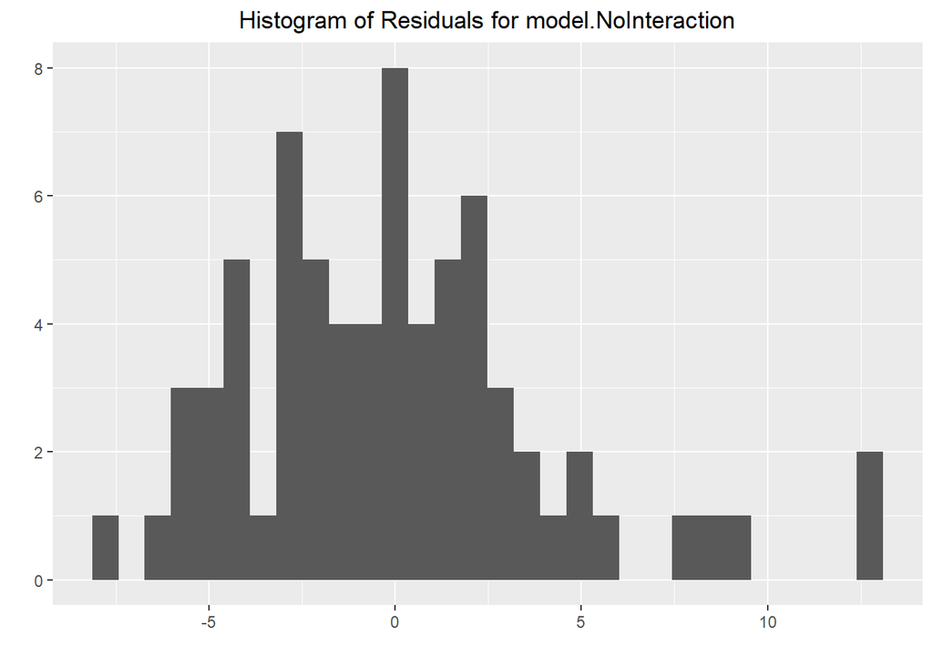

```r
# Plot location
setwd(figure_directory)

# Data to fit
data_modified_team <- team_data %>%
  select(TeamScore,
         params$dependent_response_team,
         params$dependent_response_DominateStrategy,
         Target,
         SessionOrder,
         Team)

# Generate models with variable response
GA_data_focus_team <- data_modified_team %>%
  filter(.data[[params$dependent_response_DominateStrategy]] == params$Strategy_GA_name_WithSpace)

model.NoInteraction <- model_data_Target_Session(df = GA_data_focus_team, dependent =  params$dependent_response_team, model.type =  "NoInteraction", is.team = TRUE, is.robust = FALSE)

# Histogram of Residuals - model.NoInteraction
ggplot(model.NoInteraction, aes(x = .resid)) +
  geom_histogram(bins = 30) +
  labs(title = paste("Histogram of Residuals for model.NoInteraction"), x = "", y = "") +
  theme(plot.title = element_text(hjust = 0.5)) +
  ggsave(filename = paste("Histogram_Residuals_", params$dependent_response_name_NoSpace, "_NoInteraction_", params$Strategy_GA_name_NoSpace, "_Team.png", sep = ""))
```

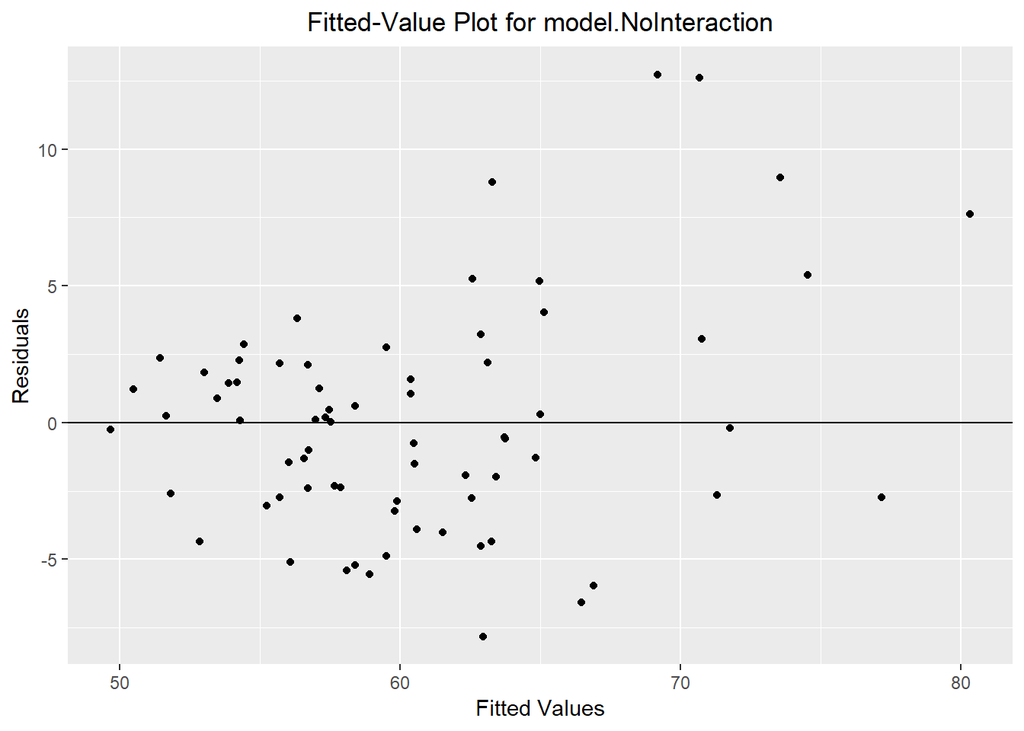

```r
# Fitted values - model.NoInteraction
ggplot(model.NoInteraction, aes(x = .fitted, y = .resid)) +
  geom_point() +
  geom_hline(yintercept = 0)+
  labs(title = paste("Fitted-Value Plot for model.NoInteraction"), x = "Fitted Values", y = "Residuals") +
  theme(plot.title = element_text(hjust = 0.5)) +
  ggsave(filename = paste("FitteValue_Residuals_", params$dependent_response_name_NoSpace, "_NoInteraction_", params$Strategy_GA_name_NoSpace, "_Team.png", sep = ""))
```

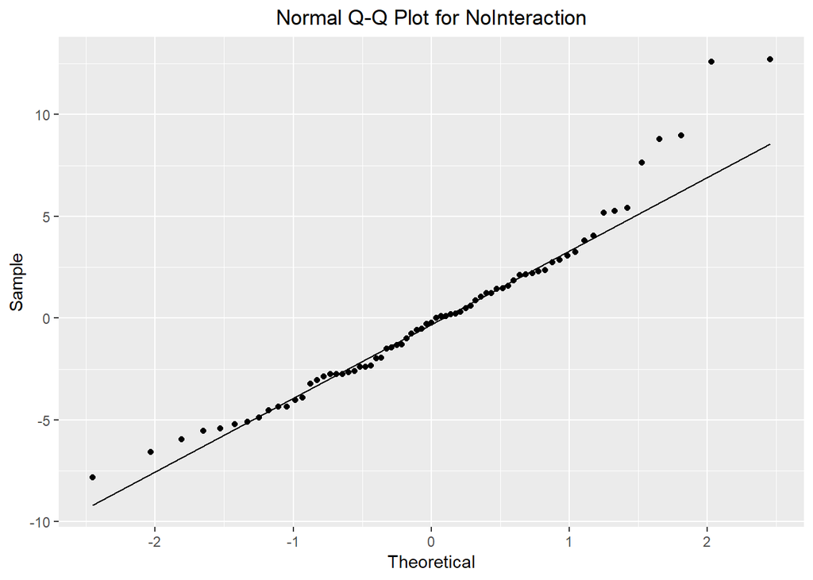

```r
# QQ plots - model.NoInteraction
ggplot(model.NoInteraction, aes(sample = .resid)) +
  stat_qq() +
  stat_qq_line()+
  labs(title = "Normal Q-Q Plot for NoInteraction", x = "Theoretical", y = "Sample") +
   theme(plot.title = element_text(hjust = 0.5)) +
  ggsave(filename = paste("QQ_Residuals_", params$dependent_response_name_NoSpace, "_NoInteraction_", params$Strategy_GA_name_NoSpace, "_Team.png", sep = ""))
```

It looks like assumption 2 and 3 are violated. Need to analysis the influence of the violation.

#### GT

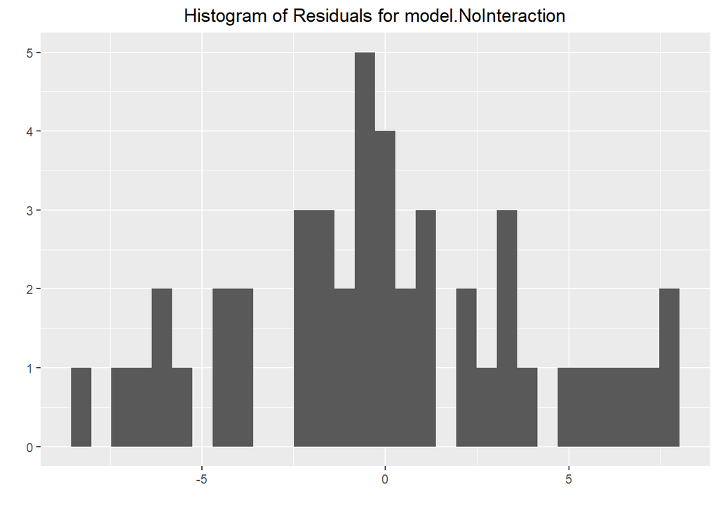

```r
# Plot location
setwd(figure_directory)

# Data to fit
data_modified_team <- team_data %>%
  select(TeamScore,
         params$dependent_response_team,
         params$dependent_response_DominateStrategy,
         Target,
         SessionOrder,
         Team)

# Generate models with variable response
GT_data_focus_team <- data_modified_team %>%
  filter(.data[[params$dependent_response_DominateStrategy]] == params$Strategy_GT_name_WithSpace)

model.NoInteraction <- model_data_Target_Session(df = GT_data_focus_team, dependent =  params$dependent_response_team, model.type =  "NoInteraction", is.team = TRUE, is.robust = FALSE)

# Histogram of Residuals - model.NoInteraction
ggplot(model.NoInteraction, aes(x = .resid)) +
  geom_histogram(bins = 30) +
  labs(title = paste("Histogram of Residuals for model.NoInteraction"), x = "", y = "") +
  theme(plot.title = element_text(hjust = 0.5)) +
  ggsave(filename = paste("Histogram_Residuals_", params$dependent_response_name_NoSpace, "_NoInteraction_", params$Strategy_GT_name_NoSpace, "_Team.png", sep = ""))
```

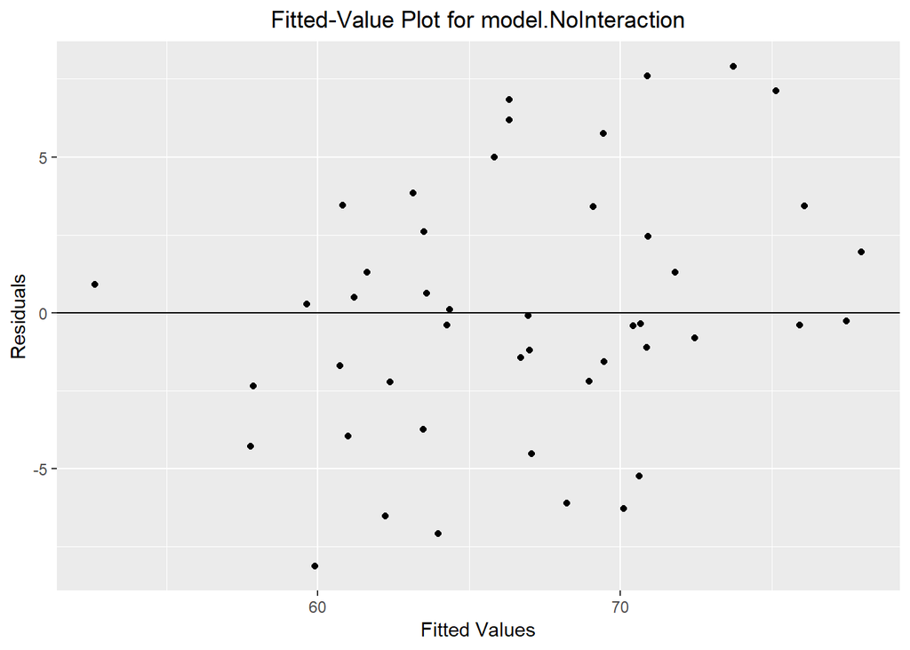

```r
# Fitted values - model.NoInteraction
ggplot(model.NoInteraction, aes(x = .fitted, y = .resid)) +
  geom_point() +
  geom_hline(yintercept = 0)+
  labs(title = paste("Fitted-Value Plot for model.NoInteraction"), x = "Fitted Values", y = "Residuals") +
  theme(plot.title = element_text(hjust = 0.5)) +
  ggsave(filename = paste("FitteValue_Residuals_", params$dependent_response_name_NoSpace, "_NoInteraction_", params$Strategy_GT_name_NoSpace, "_Team.png", sep = ""))
```

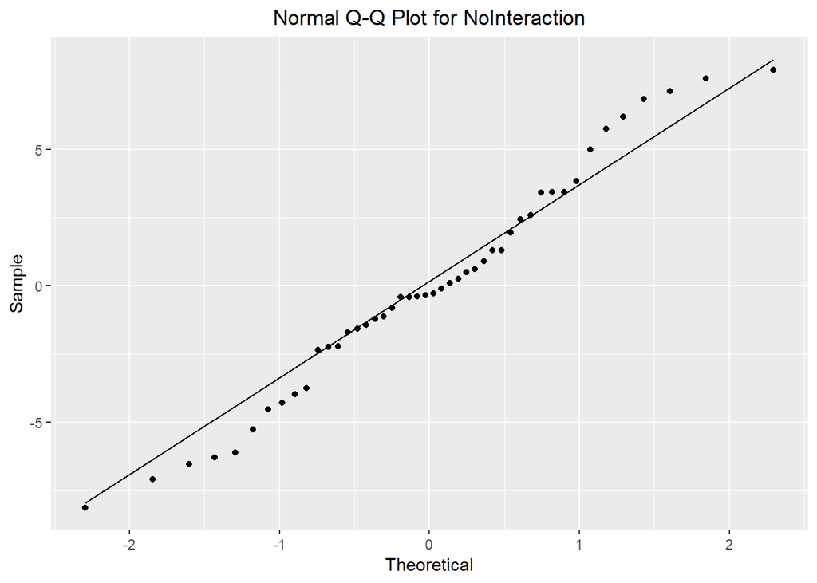

```r
# QQ plots - model.NoInteraction
ggplot(model.NoInteraction, aes(sample = .resid)) +
  stat_qq() +
  stat_qq_line()+
  labs(title = "Normal Q-Q Plot for NoInteraction", x = "Theoretical", y = "Sample") +
   theme(plot.title = element_text(hjust = 0.5)) +
  ggsave(filename = paste("QQ_Residuals_", params$dependent_response_name_NoSpace, "_NoInteraction_", params$Strategy_GT_name_NoSpace, "_Team.png", sep = ""))
```

### Model.NoInteraction.NoTarget

#### GA

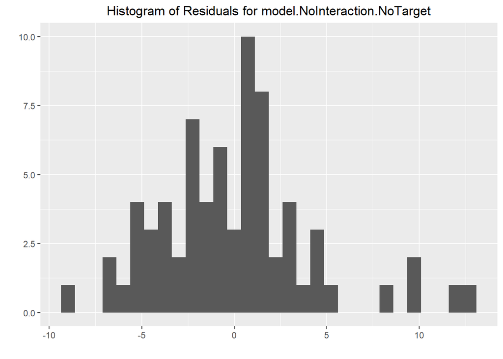

```r
# Plot location
setwd(figure_directory)

# Data to fit
data_modified_team <- team_data %>%
  select(TeamScore,
         params$dependent_response_team,
         params$dependent_response_DominateStrategy,
         Target,
         SessionOrder,
         Team)

# Generate models with variable response
GA_data_focus_team <- data_modified_team %>%
  filter(.data[[params$dependent_response_DominateStrategy]] == params$Strategy_GA_name_WithSpace)

model.NoInteraction.NoTarget <- model_data_Target_Session(df = GA_data_focus_team, dependent =  params$dependent_response_team, model.type =  "NoInteraction_NoTarget", is.team = TRUE, is.robust = FALSE)

# Histogram of Residuals - model.NoInteraction.NoTarget
ggplot(model.NoInteraction.NoTarget, aes(x = .resid)) +
  geom_histogram(bins = 30) +
  labs(title = paste("Histogram of Residuals for model.NoInteraction.NoTarget"), x = "", y = "") +
  theme(plot.title = element_text(hjust = 0.5)) +
  ggsave(filename = paste("Histogram_Residuals_", params$dependent_response_name_NoSpace, "_NoInteraction_", params$Strategy_GA_name_NoSpace, "_Team.png", sep = ""))
```

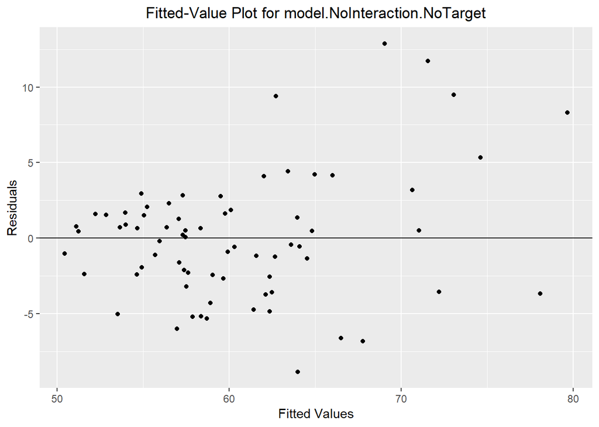

```r
# Fitted values - model.NoInteraction.NoTarget
ggplot(model.NoInteraction.NoTarget, aes(x = .fitted, y = .resid)) +
  geom_point() +
  geom_hline(yintercept = 0)+
  labs(title = paste("Fitted-Value Plot for model.NoInteraction.NoTarget"), x = "Fitted Values", y = "Residuals") +
  theme(plot.title = element_text(hjust = 0.5)) +
  ggsave(filename = paste("FitteValue_Residuals_", params$dependent_response_name_NoSpace, "_NoInteraction_", params$Strategy_GA_name_NoSpace, "_Team.png", sep = ""))
```

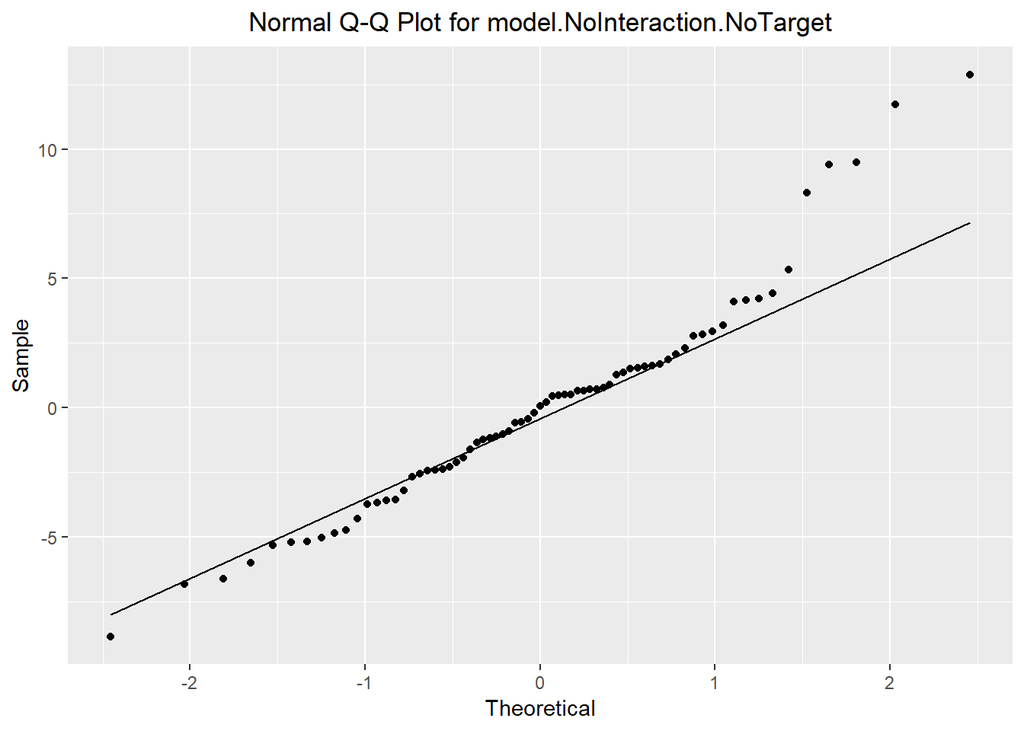

```r
# QQ plots - model.NoInteraction.NoTarget
ggplot(model.NoInteraction.NoTarget, aes(sample = .resid)) +
  stat_qq() +
  stat_qq_line()+
  labs(title = "Normal Q-Q Plot for model.NoInteraction.NoTarget", x = "Theoretical", y = "Sample") +
   theme(plot.title = element_text(hjust = 0.5)) +
  ggsave(filename = paste("QQ_Residuals_", params$dependent_response_name_NoSpace, "_NoInteraction_", params$Strategy_GA_name_NoSpace, "_Team.png", sep = ""))
```

It looks like assumption 2 and 3 are violated. Need to analysis the influence of the violation.

#### GT

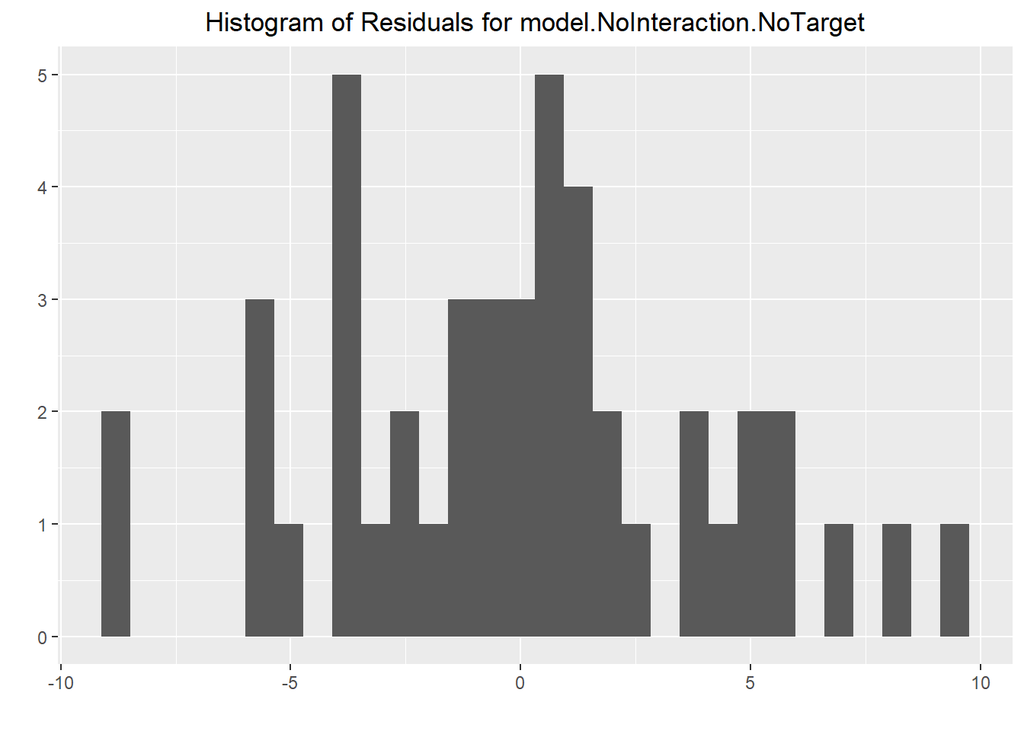

```r
# Plot location
setwd(figure_directory)

# Data to fit
data_modified_team <- team_data %>%
  select(TeamScore,
         params$dependent_response_team,
         params$dependent_response_DominateStrategy,
         Target,
         SessionOrder,
         Team)

# Generate models with variable response
GT_data_focus_team <- data_modified_team %>%
  filter(.data[[params$dependent_response_DominateStrategy]] == params$Strategy_GT_name_WithSpace)

model.NoInteraction.NoTarget <- model_data_Target_Session(df = GT_data_focus_team, dependent =  params$dependent_response_team, model.type =  "NoInteraction_NoTarget", is.team = TRUE, is.robust = FALSE)

# Histogram of Residuals - model.NoInteraction.NoTarget
ggplot(model.NoInteraction.NoTarget, aes(x = .resid)) +
  geom_histogram(bins = 30) +
  labs(title = paste("Histogram of Residuals for model.NoInteraction.NoTarget"), x = "", y = "") +
  theme(plot.title = element_text(hjust = 0.5)) +
  ggsave(filename = paste("Histogram_Residuals_", params$dependent_response_name_NoSpace, "_NoInteraction_", params$Strategy_GT_name_NoSpace, "_Team.png", sep = ""))
```

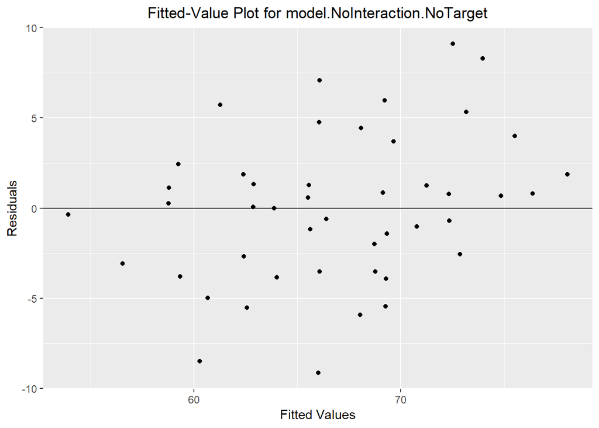

```r
# Fitted values - model.NoInteraction.NoTarget
ggplot(model.NoInteraction.NoTarget, aes(x = .fitted, y = .resid)) +
  geom_point() +
  geom_hline(yintercept = 0)+
  labs(title = paste("Fitted-Value Plot for model.NoInteraction.NoTarget"), x = "Fitted Values", y = "Residuals") +
  theme(plot.title = element_text(hjust = 0.5)) +
  ggsave(filename = paste("FitteValue_Residuals_", params$dependent_response_name_NoSpace, "_NoInteraction_", params$Strategy_GT_name_NoSpace, "_Team.png", sep = ""))
```

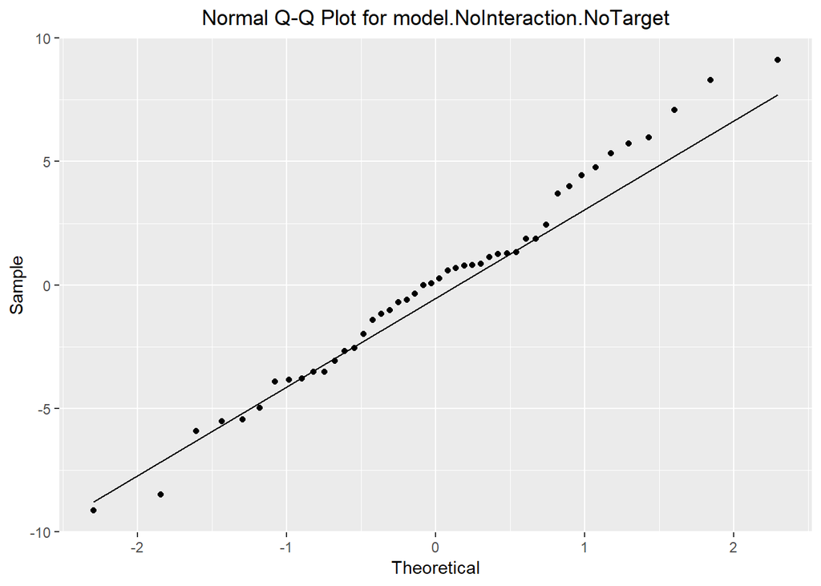

```r
# QQ plots - model.NoInteraction.NoTarget
ggplot(model.NoInteraction.NoTarget, aes(sample = .resid)) +
  stat_qq() +
  stat_qq_line()+
  labs(title = "Normal Q-Q Plot for model.NoInteraction.NoTarget", x = "Theoretical", y = "Sample") +
   theme(plot.title = element_text(hjust = 0.5)) +
  ggsave(filename = paste("QQ_Residuals_", params$dependent_response_name_NoSpace, "_NoInteraction_", params$Strategy_GT_name_NoSpace, "_Team.png", sep = ""))
```

It looks like assumption 3 was violated. Need to analysis the influence of the violation.

## Individual

We learned that **model.NoInteraction** and **model.NoInteraction.NoTarget** best describe the individual level data(see previous analysis).

### Model.NoInteraction

#### GA

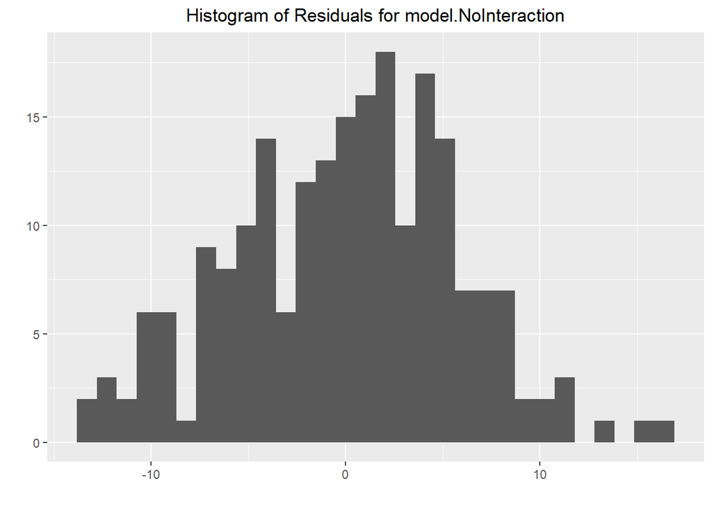

```r
# Plot location
setwd(figure_directory)

# Data to model
data_modified_ind <- ind_data %>%
  select(params$dependent_response_ind,
         params$dependent_response_DominateStrategy,
         Target,
         SessionOrder,
         Team,
         Player_ID)

# Generate models with variable response
GA_data_focus_ind <- data_modified_ind %>%
  filter(.data[[params$dependent_response_DominateStrategy]] == params$Strategy_GA_name_WithSpace)

model.NoInteraction <- model_data_Target_Session(df = GA_data_focus_ind, dependent =  params$dependent_response_ind, model.type =  "NoInteraction", is.team = FALSE, is.robust = FALSE)

# Histogram of Residuals - model.NoInteraction
ggplot(model.NoInteraction, aes(x = .resid)) +
  geom_histogram(bins = 30) +
  labs(title = paste("Histogram of Residuals for model.NoInteraction"), x = "", y = "") +
  theme(plot.title = element_text(hjust = 0.5)) +
  ggsave(paste("Histogram_Residuals_", params$dependent_response_name_NoSpace, "_NoInteraction_", params$Strategy_GA_name_NoSpace, "_Ind.png", sep =""))
```

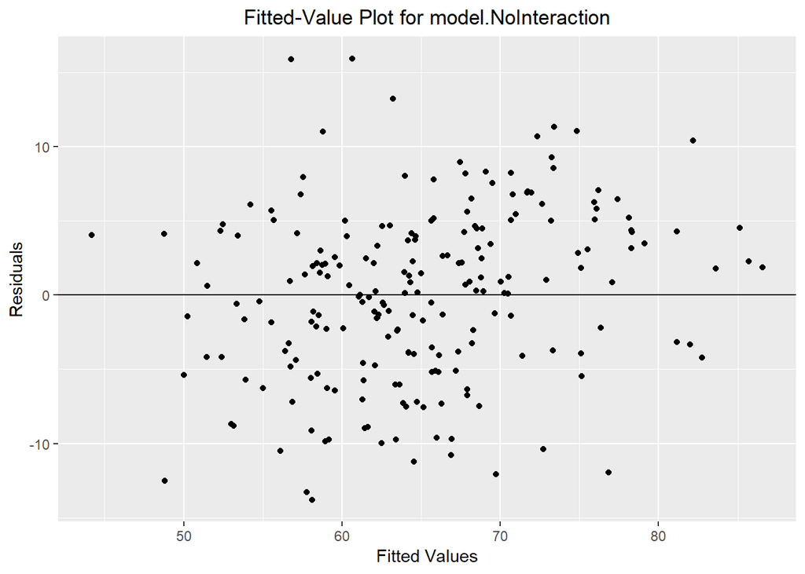

```r
# Fitted values - model.NoInteraction
ggplot(model.NoInteraction, aes(x = .fitted, y = .resid)) +
  geom_point() +
  geom_hline(yintercept = 0)+
  labs(title = paste("Fitted-Value Plot for model.NoInteraction"), x = "Fitted Values", y = "Residuals") +
  theme(plot.title = element_text(hjust = 0.5)) +
  ggsave(paste("FittedValue_Residuals_", params$dependent_response_name_NoSpace, "_NoInteraction_", params$Strategy_GA_name_NoSpace, "_Ind.png", sep =""))
```

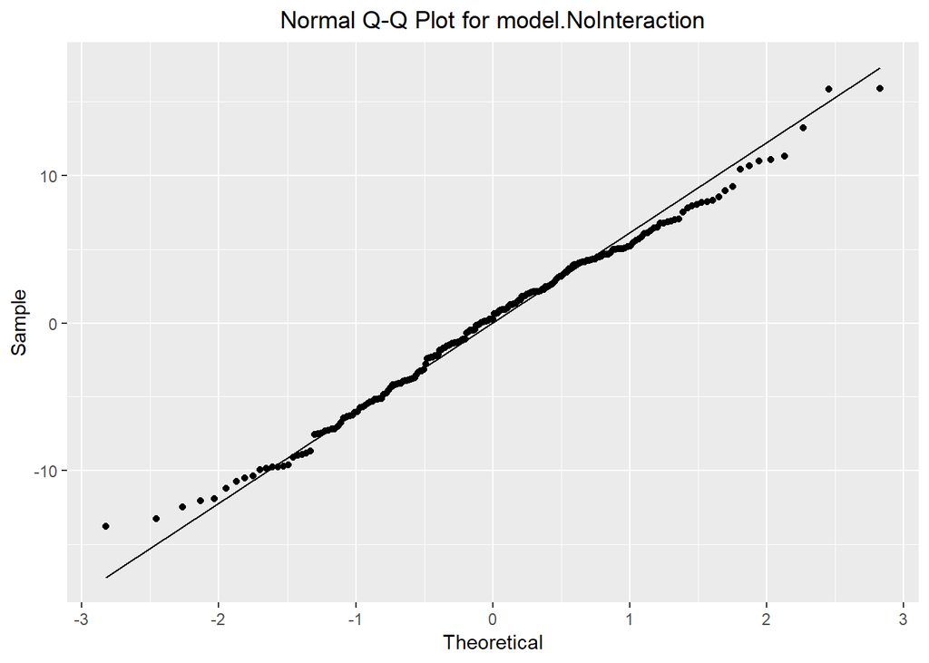

```r
# QQ plots - model.NoInteraction
ggplot(model.NoInteraction, aes(sample = .resid)) +
  stat_qq() +
  stat_qq_line()+
  labs(title = "Normal Q-Q Plot for model.NoInteraction", x = "Theoretical", y = "Sample") +
   theme(plot.title = element_text(hjust = 0.5)) +
  ggsave(paste("QQ_Residuals_", params$dependent_response_name_NoSpace, "_NoInteraction_", params$Strategy_GA_name_NoSpace, "_Ind.png", sep =""))
```

It looks like assumption 3 was violated. Need to analysis the influence of the violation.

#### GT

```r
# Plot location
setwd(figure_directory)

# Data to model
data_modified_ind <- ind_data %>%
  select(params$dependent_response_ind,
         params$dependent_response_DominateStrategy,
         Target,
         SessionOrder,
         Team,
         Player_ID)

# Generate models with variable response
GT_data_focus_ind <- data_modified_ind %>%
  filter(.data[[params$dependent_response_DominateStrategy]] == params$Strategy_GT_name_WithSpace)

model.NoInteraction <- model_data_Target_Session(df = GT_data_focus_ind, dependent =  params$dependent_response_ind, model.type =  "NoInteraction", is.team = FALSE, is.robust = FALSE)
```

```
## boundary (singular) fit: see ?isSingular
```

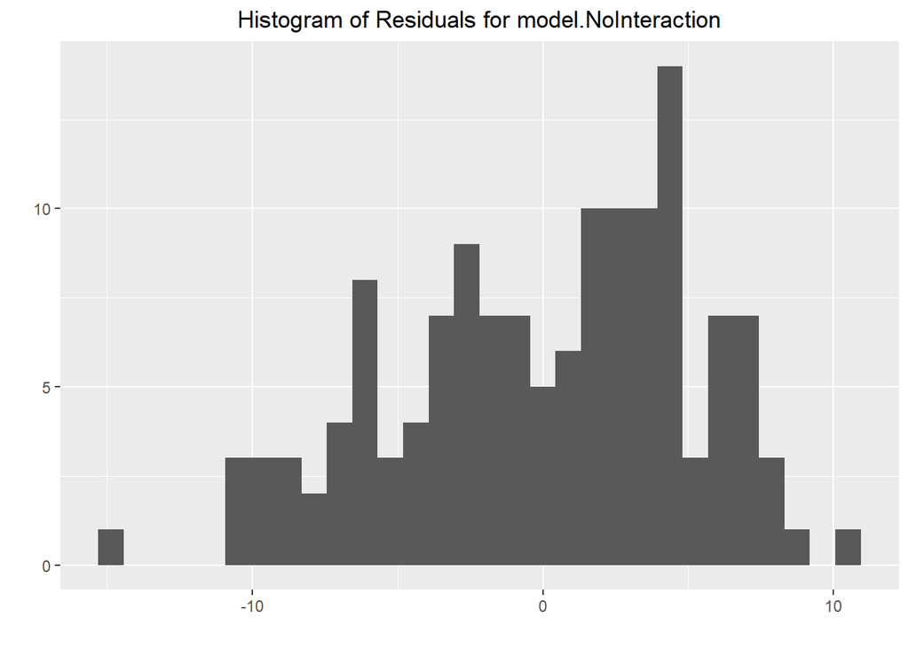

```r
# Histogram of Residuals - model.NoInteraction
ggplot(model.NoInteraction, aes(x = .resid)) +
  geom_histogram(bins = 30) +
  labs(title = paste("Histogram of Residuals for model.NoInteraction"), x = "", y = "") +
  theme(plot.title = element_text(hjust = 0.5)) +
  ggsave(paste("Histogram_Residuals_", params$dependent_response_name_NoSpace, "_NoInteraction_", params$Strategy_GT_name_NoSpace , "Ind.png", sep =""))
```

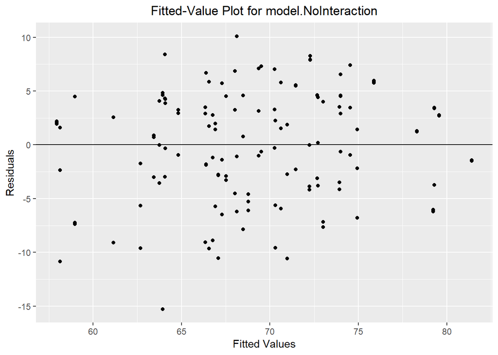

```r
# Fitted values - model.NoInteraction
ggplot(model.NoInteraction, aes(x = .fitted, y = .resid)) +
  geom_point() +
  geom_hline(yintercept = 0)+
  labs(title = paste("Fitted-Value Plot for model.NoInteraction"), x = "Fitted Values", y = "Residuals") +
  theme(plot.title = element_text(hjust = 0.5)) +
  ggsave(paste("FittedValue_Residuals_", params$dependent_response_name_NoSpace, "_NoInteraction_", params$Strategy_GT_name_NoSpace , "Ind.png", sep =""))
```

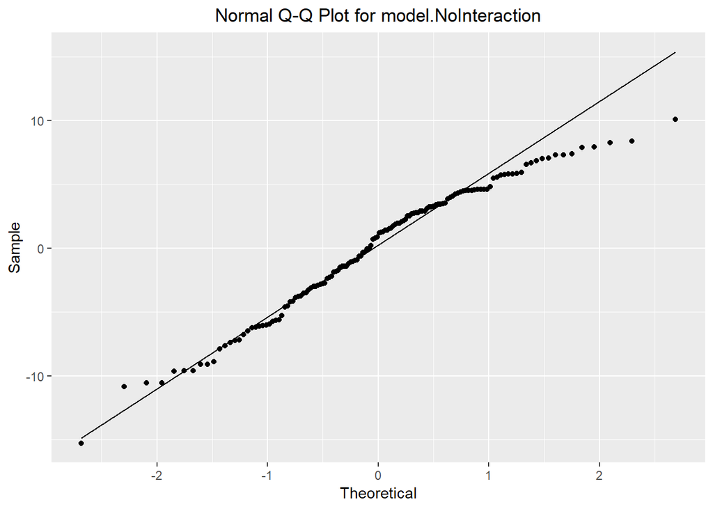

```r
# QQ plots - model.NoInteraction
ggplot(model.NoInteraction, aes(sample = .resid)) +
  stat_qq() +
  stat_qq_line()+
  labs(title = "Normal Q-Q Plot for model.NoInteraction", x = "Theoretical", y = "Sample") +
   theme(plot.title = element_text(hjust = 0.5)) +
  ggsave(paste("QQ_Residuals_", params$dependent_response_name_NoSpace, "_NoInteraction_", params$Strategy_GT_name_NoSpace , "Ind.png", sep =""))
```

It looks like assumption 3 was violated. Need to analysis the influence of the violation.

### Model.NoInteraction.NoTarget

#### GA

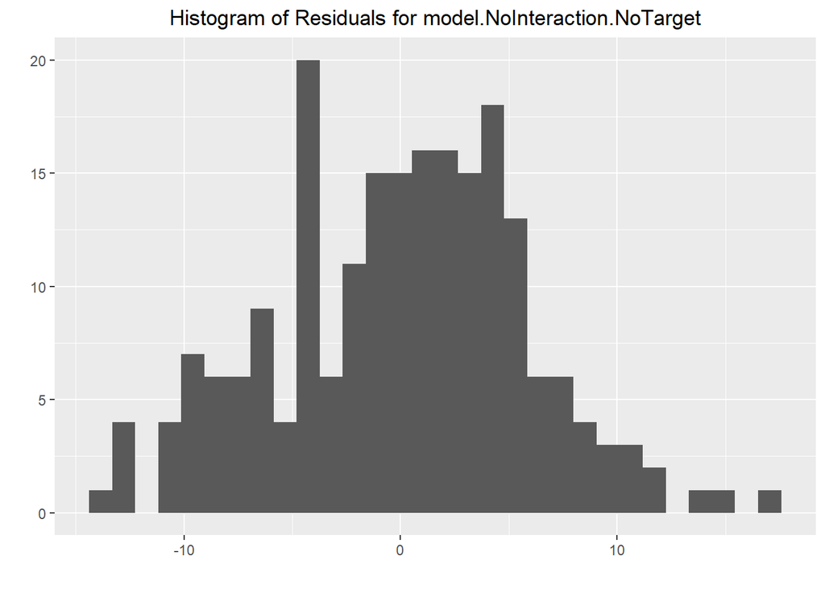

```r
# Plot location
setwd(figure_directory)

# Data to model
data_modified_ind <- ind_data %>%
  select(params$dependent_response_ind,
         params$dependent_response_DominateStrategy,
         Target,
         SessionOrder,
         Team,
         Player_ID)

# Generate models with variable response
GA_data_focus_ind <- data_modified_ind %>%
  filter(.data[[params$dependent_response_DominateStrategy]] == params$Strategy_GA_name_WithSpace)

model.NoInteraction.NoTarget <- model_data_Target_Session(df = GA_data_focus_ind, dependent =  params$dependent_response_ind, model.type =  "NoInteraction_NoTarget", is.team = FALSE, is.robust = FALSE)

# Histogram of Residuals - model.NoInteraction.NoTarget
ggplot(model.NoInteraction.NoTarget, aes(x = .resid)) +
  geom_histogram(bins = 30) +
  labs(title = paste("Histogram of Residuals for model.NoInteraction.NoTarget"), x = "", y = "") +
  theme(plot.title = element_text(hjust = 0.5)) +
  ggsave(paste("Histogram_Residuals_", params$dependent_response_name_NoSpace, "_NoInteraction_", params$Strategy_GA_name_NoSpace, "_Ind.png", sep =""))
```

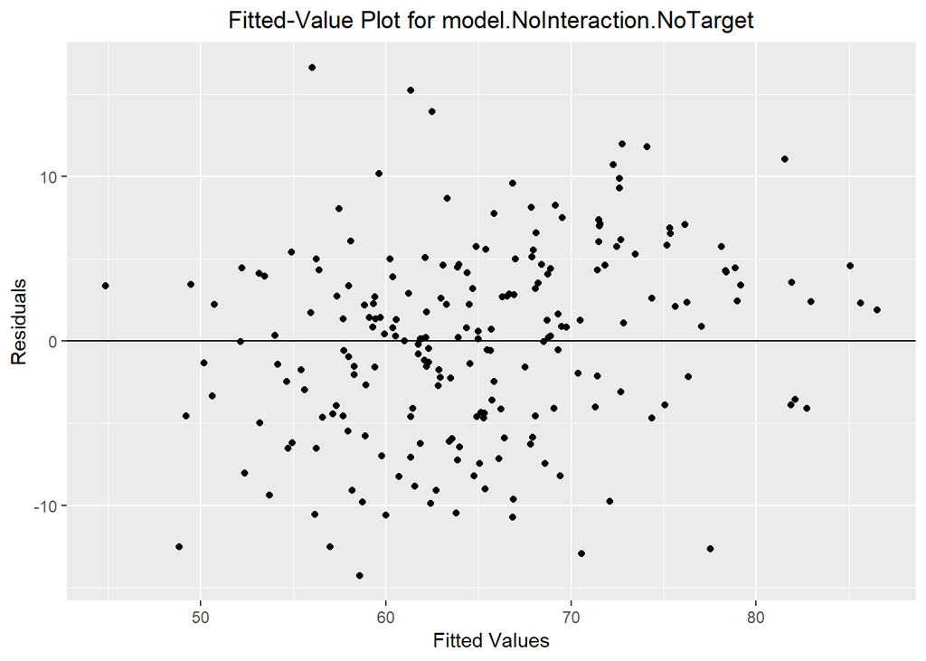

```r
# Fitted values - model.NoInteraction.NoTarget
ggplot(model.NoInteraction.NoTarget, aes(x = .fitted, y = .resid)) +
  geom_point() +
  geom_hline(yintercept = 0)+
  labs(title = paste("Fitted-Value Plot for model.NoInteraction.NoTarget"), x = "Fitted Values", y = "Residuals") +
  theme(plot.title = element_text(hjust = 0.5)) +
  ggsave(paste("FittedValue_Residuals_", params$dependent_response_name_NoSpace, "_NoInteraction_", params$Strategy_GA_name_NoSpace, "_Ind.png", sep =""))
```

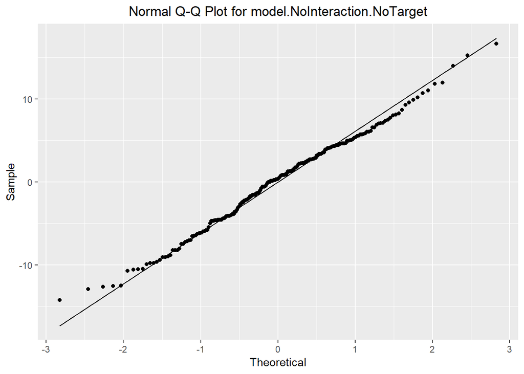

```r
# QQ plots - model.NoInteraction.NoTarget
ggplot(model.NoInteraction.NoTarget, aes(sample = .resid)) +
  stat_qq() +
  stat_qq_line()+
  labs(title = "Normal Q-Q Plot for model.NoInteraction.NoTarget", x = "Theoretical", y = "Sample") +
   theme(plot.title = element_text(hjust = 0.5)) +
  ggsave(paste("QQ_Residuals_", params$dependent_response_name_NoSpace, "_NoInteraction_", params$Strategy_GA_name_NoSpace, "_Ind.png", sep =""))
```

It looks like assumption 3 was violated. Need to analysis the influence of the violation.

#### GT

```r
# Plot location
setwd(figure_directory)

# Data to model
data_modified_ind <- ind_data %>%
  select(params$dependent_response_ind,
         params$dependent_response_DominateStrategy,
         Target,
         SessionOrder,
         Team,
         Player_ID)

# Generate models with variable response
GT_data_focus_ind <- data_modified_ind %>%
  filter(.data[[params$dependent_response_DominateStrategy]] == params$Strategy_GT_name_WithSpace)

model.NoInteraction.NoTarget <- model_data_Target_Session(df = GT_data_focus_ind, dependent =  params$dependent_response_ind, model.type =  "NoInteraction_NoTarget", is.team = FALSE, is.robust = FALSE)
```

```
## boundary (singular) fit: see ?isSingular
```

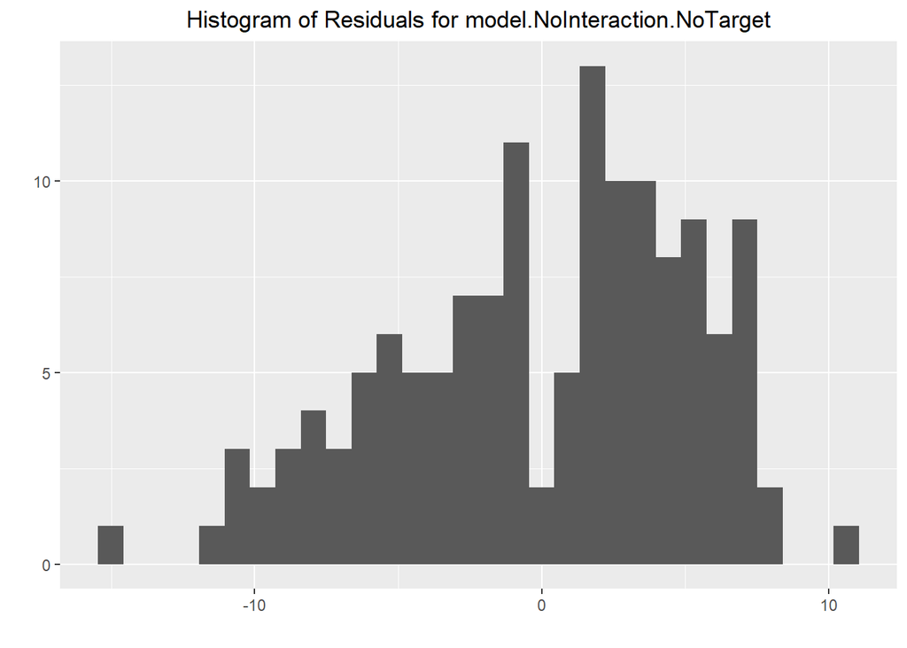

```r
# Histogram of Residuals - model.NoInteraction.NoTarget
ggplot(model.NoInteraction.NoTarget, aes(x = .resid)) +
  geom_histogram(bins = 30) +
  labs(title = paste("Histogram of Residuals for model.NoInteraction.NoTarget"), x = "", y = "") +
  theme(plot.title = element_text(hjust = 0.5)) +
  ggsave(paste("Histogram_Residuals_", params$dependent_response_name_NoSpace, "_NoInteraction_", params$Strategy_GT_name_NoSpace, "_Ind.png", sep =""))
```

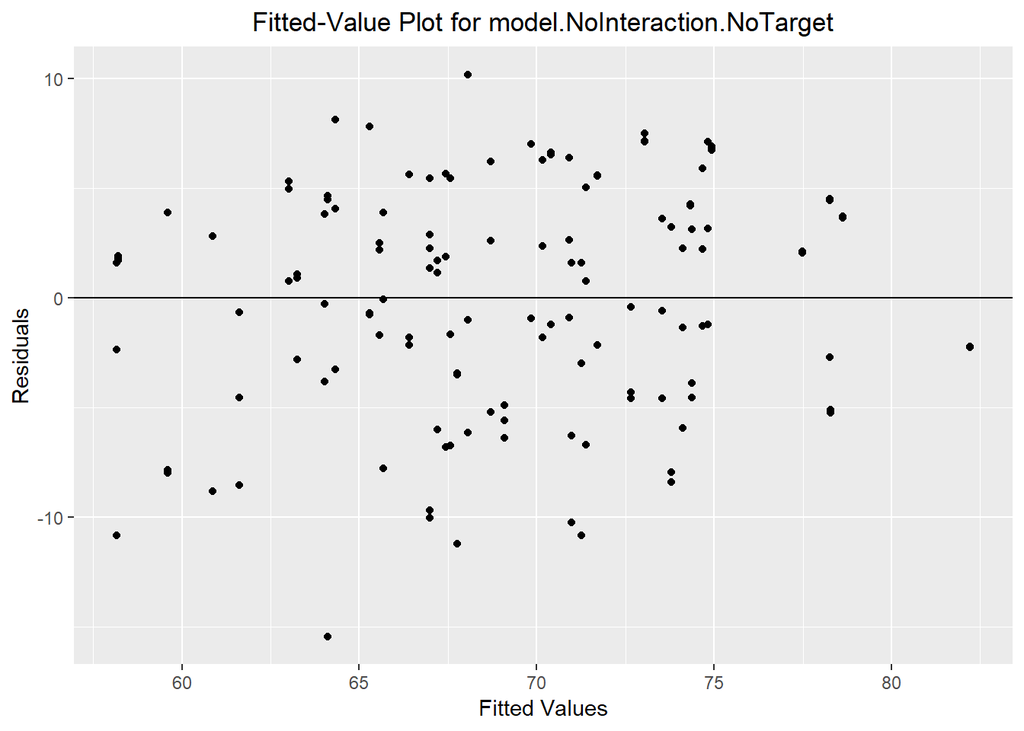

```r
# Fitted values - model.NoInteraction.NoTarget
ggplot(model.NoInteraction.NoTarget, aes(x = .fitted, y = .resid)) +
  geom_point() +
  geom_hline(yintercept = 0)+
  labs(title = paste("Fitted-Value Plot for model.NoInteraction.NoTarget"), x = "Fitted Values", y = "Residuals") +
  theme(plot.title = element_text(hjust = 0.5)) +
  ggsave(paste("FittedValue_Residuals_", params$dependent_response_name_NoSpace, "_NoInteraction_", params$Strategy_GT_name_NoSpace, "_Ind.png", sep =""))
```

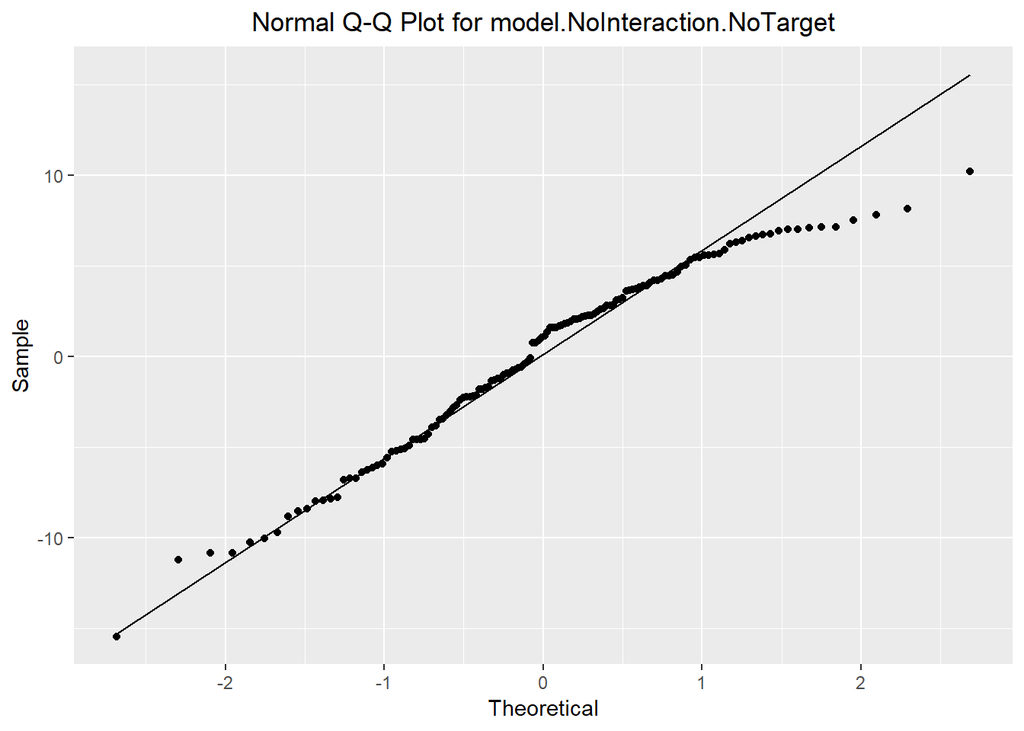

```r
# QQ plots - model.NoInteraction.NoTarget
ggplot(model.NoInteraction.NoTarget, aes(sample = .resid)) +
  stat_qq() +
  stat_qq_line()+
  labs(title = "Normal Q-Q Plot for model.NoInteraction.NoTarget", x = "Theoretical", y = "Sample") +
   theme(plot.title = element_text(hjust = 0.5)) +
  ggsave(paste("QQ_Residuals_", params$dependent_response_name_NoSpace, "_NoInteraction_", params$Strategy_GT_name_NoSpace, "_Ind.png", sep =""))
```

It looks like assumption 1 and 3 were violated. Need to analysis the influence of the violation.

## Summary

Overall, it looks like every model for every group (i.e., Go Together and Go Alone) violates one or more assumptions. The next step is to see if the violations influence the model.

# Q: Does the violation influence the linear model estimation?

I will use the robust estimation for linear mixed models found in the robustlmm package by Koller (2016). I will then compare the robust model to the non-robust model. If the estimated values are noticeably different, then data will need to be transformed.

## Team

### Model.NoInteraction

#### GA

```r
# Data to fit
data_modified_team <- team_data %>%
  select(TeamScore,
         params$dependent_response_team,
         params$dependent_response_DominateStrategy,
         Target,
         SessionOrder,
         Team)

# Generate models with variable response
GA_data_focus_team <- data_modified_team %>%
  filter(.data[[params$dependent_response_DominateStrategy]] == params$Strategy_GA_name_WithSpace)

# Generate robust and non-robust models - NoInteraction
model.NoInteraction <- model_data_Target_Session(df = GA_data_focus_team, dependent =  params$dependent_response_team, model.type =  "NoInteraction", is.team = TRUE, is.robust = FALSE)
rmodel.NoInteraction <- model_data_Target_Session(df = GA_data_focus_team, dependent =  params$dependent_response_team, model.type =  "NoInteraction", is.team = TRUE, is.robust = TRUE)

comparision_results <- compare(model.NoInteraction, rmodel.NoInteraction, show.rho.functions = FALSE)

comparision_results %>%
  kable(caption = "model.NoInteraction") %>%
  kable_styling()
```

model.NoInteraction

|  | model.NoInteraction | rmodel.NoInteraction |
| --- | --- | --- |
| Coef |  |  |
| (Intercept) | 58.098 (1.79) | 57.438 (1.46) |
| TargetInd_Team | -1.588 (1.52) | -1.806 (1.34) |
| TargetTeam | -0.578 (1.52) | -0.704 (1.33) |
| SessionOrder3 | 2.216 (1.51) | 1.781 (1.32) |
| SessionOrder4 | 7.423 (1.52) | 6.258 (1.34) |
| VarComp |  |  |
| (Intercept) \| Team | 6.08 | 4.29 |
| sigma | 5.09 | 4.38 |
| REML | 456 |  |

I do not see a concerning difference. I will not transform the data.

#### GT

```r
# Data to fit
data_modified_team <- team_data %>%
  select(TeamScore,
         params$dependent_response_team,
         params$dependent_response_DominateStrategy,
         Target,
         SessionOrder,
         Team)

# Generate models with variable response
GT_data_focus_team <- data_modified_team %>%
  filter(.data[[params$dependent_response_DominateStrategy]] == params$Strategy_GT_name_WithSpace)

# Generate robust and non-robust models - NoInteraction
model.NoInteraction <- model_data_Target_Session(df = GT_data_focus_team, dependent =  params$dependent_response_team, model.type =  "NoInteraction", is.team = TRUE, is.robust = FALSE)
rmodel.NoInteraction <- model_data_Target_Session(df = GT_data_focus_team, dependent =  params$dependent_response_team, model.type =  "NoInteraction", is.team = TRUE, is.robust = TRUE)

comparision_results <- compare(model.NoInteraction, rmodel.NoInteraction, show.rho.functions = FALSE)

comparision_results %>%
  kable(caption = "model.NoInteraction") %>%
  kable_styling()
```

model.NoInteraction

|  | model.NoInteraction | rmodel.NoInteraction |
| --- | --- | --- |
| Coef |  |  |
| (Intercept) | 58.63 (2.08) | 58.71 (2.22) |
| TargetInd_Team | 2.29 (1.89) | 2.24 (2.03) |
| TargetTeam | 3.41 (1.95) | 3.25 (2.09) |
| SessionOrder3 | 6.19 (1.99) | 6.16 (2.14) |
| SessionOrder4 | 9.35 (1.97) | 9.32 (2.11) |
| VarComp |  |  |
| (Intercept) \| Team | 5.04 | 5.19 |
| sigma | 5.05 | 5.3 |
| REML | 283 |  |

I do not see a concerning difference. I will not transform the data.

### Model.NoInteraction.NoTarget

#### GA

```r
# Data to fit
data_modified_team <- team_data %>%
  select(TeamScore,
         params$dependent_response_team,
         params$dependent_response_DominateStrategy,
         Target,
         SessionOrder,
         Team)

# Generate models with variable response
GA_data_focus_team <- data_modified_team %>%
  filter(.data[[params$dependent_response_DominateStrategy]] == params$Strategy_GA_name_WithSpace)

# Generate robust and non-robust models - NoInteraction
model.NoInteraction.NoTarget <- model_data_Target_Session(df = GA_data_focus_team, dependent =  params$dependent_response_team, model.type =  "NoInteraction_NoTarget", is.team = TRUE, is.robust = FALSE)
rmodel.NoInteraction.NoTarget <- model_data_Target_Session(df = GA_data_focus_team, dependent =  params$dependent_response_team, model.type =  "NoInteraction_NoTarget", is.team = TRUE, is.robust = TRUE)

comparision_results <- compare(model.NoInteraction.NoTarget, rmodel.NoInteraction.NoTarget, show.rho.functions = FALSE)

comparision_results %>%
  kable(caption = "model.NoInteraction.NoTarget") %>%
  kable_styling()
```

model.NoInteraction.NoTarget

|  | model.NoInteraction.NoTarget | rmodel.NoInteraction.NoTarget |
| --- | --- | --- |
| Coef |  |  |
| (Intercept) | 57.34 (1.54) | 56.61 (1.23) |
| SessionOrder3 | 2.40 (1.48) | 1.92 (1.30) |
| SessionOrder4 | 7.45 (1.51) | 6.30 (1.32) |
| VarComp |  |  |
| (Intercept) \| Team | 6.11 | 4.39 |
| sigma | 5.03 | 4.33 |
| REML | 462 |  |

I do not see a concerning difference. I will not transform the data.

#### GT

```r
# Data to fit
data_modified_team <- team_data %>%
  select(TeamScore,
         params$dependent_response_team,
         params$dependent_response_DominateStrategy,
         Target,
         SessionOrder,
         Team)

# Generate models with variable response
GT_data_focus_team <- data_modified_team %>%
  filter(.data[[params$dependent_response_DominateStrategy]] == params$Strategy_GT_name_WithSpace)

# Generate robust and non-robust models - NoInteraction
model.NoInteraction.NoTarget <- model_data_Target_Session(df = GT_data_focus_team, dependent =  params$dependent_response_team, model.type =  "NoInteraction_NoTarget", is.team = TRUE, is.robust = FALSE)
rmodel.NoInteraction.NoTarget <- model_data_Target_Session(df = GT_data_focus_team, dependent =  params$dependent_response_team, model.type =  "NoInteraction_NoTarget", is.team = TRUE, is.robust = TRUE)

comparision_results <- compare(model.NoInteraction.NoTarget, rmodel.NoInteraction.NoTarget, show.rho.functions = FALSE)

comparision_results %>%
  kable(caption = "model.NoInteraction.NoTarget") %>%
  kable_styling()
```

model.NoInteraction.NoTarget

|  | model.NoInteraction.NoTarget | rmodel.NoInteraction.NoTarget |
| --- | --- | --- |
| Coef |  |  |
| (Intercept) | 60.05 (1.94) | 60.12 (1.96) |
| SessionOrder3 | 6.77 (1.94) | 6.96 (1.89) |
| SessionOrder4 | 9.97 (1.93) | 9.74 (1.88) |
| VarComp |  |  |
| (Intercept) \| Team | 5.37 | 5.53 |
| sigma | 5.02 | 4.76 |
| REML | 292 |  |

I do not see a concerning difference. I will not transform the data.

## Individual

### Model.NoInteraction

#### GA

```r
#response_variable <- "II_ind"

# Data to model
data_modified_ind <- ind_data %>%
  select(params$dependent_response_ind,
         params$dependent_response_DominateStrategy,
         Target,
         SessionOrder,
         Team,
         Player_ID)

# Generate models with variable response
GA_data_focus_ind <- data_modified_ind %>%
  filter(.data[[params$dependent_response_DominateStrategy]] == params$Strategy_GA_name_WithSpace)

model.NoInteraction <- model_data_Target_Session(df = GA_data_focus_ind, dependent =  params$dependent_response_ind, model.type =  "NoInteraction", is.team = FALSE, is.robust = FALSE)
rmodel.NoInteraction <- model_data_Target_Session(df = GA_data_focus_ind, dependent =  params$dependent_response_ind, model.type =  "NoInteraction", is.team = FALSE, is.robust = TRUE)

comparision_results <- compare(model.NoInteraction, rmodel.NoInteraction, show.rho.functions = FALSE)

comparision_results %>%
  kable(caption = "model.NoInteraction") %>%
  kable_styling()
```

model.NoInteraction

|  | model.NoInteraction | rmodel.NoInteraction |
| --- | --- | --- |
| Coef |  |  |
| (Intercept) | 61.505 (1.72) | 61.057 (1.80) |
| TargetInd_Team | -0.783 (1.15) | -0.819 (1.20) |
| TargetTeam | 0.691 (1.16) | 0.523 (1.20) |
| SessionOrder3 | 3.855 (1.15) | 4.191 (1.19) |
| SessionOrder4 | 7.507 (1.16) | 7.686 (1.20) |
| VarComp |  |  |
| (Intercept) \| Player_ID | 4.10 | 3.93 |
| (Intercept) \| Team | 6.80 | 7.01 |
| sigma | 6.64 | 6.71 |
| REML | 1494 |  |

I do not see a concerning difference. I will not transform the data.

#### GT

```r
#response_variable <- "II_ind"

# Data to model
data_modified_ind <- ind_data %>%
  select(params$dependent_response_ind,
         params$dependent_response_DominateStrategy,
         Target,
         SessionOrder,
         Team,
         Player_ID)

# Generate models with variable response
GT_data_focus_ind <- data_modified_ind %>%
  filter(.data[[params$dependent_response_DominateStrategy]] == params$Strategy_GT_name_WithSpace)

model.NoInteraction <- model_data_Target_Session(df = GT_data_focus_ind, dependent =  params$dependent_response_ind, model.type =  "NoInteraction", is.team = FALSE, is.robust = FALSE)
```

```
## boundary (singular) fit: see ?isSingular
```

```r
rmodel.NoInteraction <- model_data_Target_Session(df = GT_data_focus_ind, dependent =  params$dependent_response_ind, model.type =  "NoInteraction", is.team = FALSE, is.robust = TRUE)
```

```
## boundary (singular) fit: see ?isSingular
```

```r
comparision_results <- compare(model.NoInteraction, rmodel.NoInteraction, show.rho.functions = FALSE)

comparision_results %>%
  kable(caption = "model.NoInteraction") %>%
  kable_styling()
```

model.NoInteraction

|  | model.NoInteraction | rmodel.NoInteraction |
| --- | --- | --- |
| Coef |  |  |
| (Intercept) | 64.412 (1.78) | 64.79 (1.78) |
| TargetInd_Team | -0.356 (1.21) | -0.15 (1.30) |
| TargetTeam | 1.375 (1.26) | 1.43 (1.36) |
| SessionOrder3 | 3.377 (1.28) | 3.52 (1.38) |
| SessionOrder4 | 7.228 (1.27) | 7.08 (1.37) |
| VarComp |  |  |
| (Intercept) \| Player_ID | 0.00 | 0.00 |
| (Intercept) \| Team | 5.97 | 5.51 |
| sigma | 5.54 | 5.85 |
| REML | 889 |  |

I do not see a concerning difference. I will not transform the data.

### Model.NoInteraction.NoTarget

#### GA

```r
#response_variable <- "II_ind"

# Data to model
data_modified_ind <- ind_data %>%
  select(params$dependent_response_ind,
         params$dependent_response_DominateStrategy,
         Target,
         SessionOrder,
         Team,
         Player_ID)

# Generate models with variable response
GA_data_focus_ind <- data_modified_ind %>%
  filter(.data[[params$dependent_response_DominateStrategy]] == params$Strategy_GA_name_WithSpace)

model.NoInteraction.NoTarget <- model_data_Target_Session(df = GA_data_focus_ind, dependent =  params$dependent_response_ind, model.type =  "NoInteraction_NoTarget", is.team = FALSE, is.robust = FALSE)
rmodel.NoInteraction.NoTarget <- model_data_Target_Session(df = GA_data_focus_ind, dependent =  params$dependent_response_ind, model.type =  "NoInteraction_NoTarget", is.team = FALSE, is.robust = TRUE)

comparision_results <- compare(model.NoInteraction.NoTarget, rmodel.NoInteraction.NoTarget, show.rho.functions = FALSE)

comparision_results %>%
  kable(caption = "model.NoInteraction") %>%
  kable_styling()
```

model.NoInteraction

|  | model.NoInteraction.NoTarget | rmodel.NoInteraction.NoTarget |
| --- | --- | --- |
| Coef |  |  |
| (Intercept) | 61.46 (1.58) | 60.97 (1.66) |
| SessionOrder3 | 3.99 (1.14) | 4.29 (1.17) |
| SessionOrder4 | 7.54 (1.16) | 7.61 (1.19) |
| VarComp |  |  |
| (Intercept) \| Player_ID | 4.11 | 4.00 |
| (Intercept) \| Team | 6.83 | 7.03 |
| sigma | 6.63 | 6.65 |
| REML | 1500 |  |

I do not see a concerning difference. I will not transform the data.

#### GT

```r
#response_variable <- "II_ind"

# Data to model
data_modified_ind <- ind_data %>%
  select(params$dependent_response_ind,
         params$dependent_response_DominateStrategy,
         Target,
         SessionOrder,
         Team,
         Player_ID)

# Generate models with variable response
GT_data_focus_ind <- data_modified_ind %>%
  filter(.data[[params$dependent_response_DominateStrategy]] == params$Strategy_GT_name_WithSpace)

model.NoInteraction.NoTarget <- model_data_Target_Session(df = GT_data_focus_ind, dependent =  params$dependent_response_ind, model.type =  "NoInteraction_NoTarget", is.team = FALSE, is.robust = FALSE)
```

```
## boundary (singular) fit: see ?isSingular
```

```r
rmodel.NoInteraction.NoTarget <- model_data_Target_Session(df = GT_data_focus_ind, dependent =  params$dependent_response_ind, model.type =  "NoInteraction_NoTarget", is.team = FALSE, is.robust = TRUE)
```

```
## boundary (singular) fit: see ?isSingular
```

```r
comparision_results <- compare(model.NoInteraction.NoTarget, rmodel.NoInteraction.NoTarget, show.rho.functions = FALSE)

comparision_results %>%
  kable(caption = "model.NoInteraction") %>%
  kable_styling()
```

model.NoInteraction

|  | model.NoInteraction.NoTarget | rmodel.NoInteraction.NoTarget |
| --- | --- | --- |
| Coef |  |  |
| (Intercept) | 64.67 (1.71) | 65.17 (1.69) |
| SessionOrder3 | 3.42 (1.25) | 3.56 (1.35) |
| SessionOrder4 | 7.38 (1.25) | 7.29 (1.35) |
| VarComp |  |  |
| (Intercept) \| Player_ID | 0.00 | 0.00 |
| (Intercept) \| Team | 6.04 | 5.56 |
| sigma | 5.54 | 5.84 |
| REML | 895 |  |

I do not see a concerning difference. I will not transform the data.

## Summary

Overall, I do not see a concerning difference for any of the violoations. I will not transform the data.

# Q: Are there any effects that are significant?

I want to determine if Target has a significant effect. I will examine the model itself, and then I will calculate the estimated marginal means to compare all three levels.

## Team

### Model.NoInteraction

#### GA

```r
# Data to fit
data_modified_team <- team_data %>%
  select(TeamScore,
         params$dependent_response_team,
         params$dependent_response_DominateStrategy,
         Target,
         SessionOrder,
         Team)

# Generate models with variable response
GA_data_focus_team <- data_modified_team %>%
  filter(.data[[params$dependent_response_DominateStrategy]] == params$Strategy_GA_name_WithSpace)

# Generate robust and non-robust models - NoInteraction
model.NoInteraction <- model_data_Target_Session(df = GA_data_focus_team, dependent =  params$dependent_response_team, model.type =  "NoInteraction", is.team = TRUE, is.robust = FALSE)

summary(model.NoInteraction)
```

```
## Linear mixed model fit by REML. t-tests use Satterthwaite's method [
## lmerModLmerTest]
## Formula:
## as.formula(paste(dependent, "~ Target + SessionOrder + (1|Team)"))
##    Data: df
##
## REML criterion at convergence: 456.3
##
## Scaled residuals:
##      Min       1Q   Median       3Q      Max
## -1.53486 -0.53844 -0.04121  0.41836  2.49944
##
## Random effects:
##  Groups   Name        Variance Std.Dev.
##  Team     (Intercept) 37.00    6.083
##  Residual             25.92    5.091
## Number of obs: 71, groups:  Team, 27
##
## Fixed effects:
##                Estimate Std. Error      df t value Pr(>|t|)
## (Intercept)     58.0984     1.7907 59.6166  32.445  < 2e-16 ***
## TargetInd_Team  -1.5877     1.5223 43.3896  -1.043    0.303
## TargetTeam      -0.5777     1.5207 44.5051  -0.380    0.706
## SessionOrder3    2.2164     1.5094 44.4310   1.468    0.149
## SessionOrder4    7.4230     1.5232 44.3392   4.873 1.44e-05 ***
## ---
## Signif. codes:  0 '***' 0.001 '**' 0.01 '*' 0.05 '.' 0.1 ' ' 1
##
## Correlation of Fixed Effects:
##             (Intr) TrgI_T TrgtTm SssnO3
## TargtInd_Tm -0.443
## TargetTeam  -0.436  0.503
## SessinOrdr3 -0.420  0.114  0.036
## SessinOrdr4 -0.379  0.017  0.005  0.490
```

Results show that the Target variable, in reference to the Ind level, has no significant effect. It also shows that the Session Order does not have a significant effect from session 3, in reference to session 2, but does have a significant effect from session 4.

```r
# Data to fit
data_modified_team <- team_data %>%
  select(TeamScore,
         params$dependent_response_team,
         params$dependent_response_DominateStrategy,
         Target,
         SessionOrder,
         Team)

# Generate models with variable response
GA_data_focus_team <- data_modified_team %>%
  filter(.data[[params$dependent_response_DominateStrategy]] == params$Strategy_GA_name_WithSpace)

# Generate robust and non-robust models - NoInteraction
model.NoInteraction <- model_data_Target_Session(df = GA_data_focus_team, dependent =  params$dependent_response_team, model.type =  "NoInteraction", is.team = TRUE, is.robust = FALSE)

emmeans(model.NoInteraction, list(pairwise ~ Target), adjust = "tukey")
```

```
## $`emmeans of Target`
##  Target   emmean   SE   df lower.CL upper.CL
##  Ind        61.3 1.59 47.3     58.1     64.5
##  Ind_Team   59.7 1.62 48.7     56.5     63.0
##  Team       60.7 1.59 47.3     57.5     63.9
##
## Results are averaged over the levels of: SessionOrder
## Degrees-of-freedom method: satterthwaite
## Confidence level used: 0.95
##
## $`pairwise differences of Target`
##  contrast        estimate   SE   df t.ratio p.value
##  Ind - Ind_Team     1.588 1.52 43.4  1.043  0.5542
##  Ind - Team         0.578 1.52 44.5  0.380  0.9237
##  Ind_Team - Team   -1.010 1.52 43.3 -0.666  0.7842
##
## Results are averaged over the levels of: SessionOrder
## P value adjustment: tukey method for comparing a family of 3 estimates
```

The results show no statistical difference among the Target levels.

```r
# Data to fit
data_modified_team <- team_data %>%
  select(TeamScore,
         params$dependent_response_team,
         params$dependent_response_DominateStrategy,
         Target,
         SessionOrder,
         Team)

# Generate models with variable response
GA_data_focus_team <- data_modified_team %>%
  filter(.data[[params$dependent_response_DominateStrategy]] == params$Strategy_GA_name_WithSpace)

# Generate robust and non-robust models - NoInteraction
model.NoInteraction <- model_data_Target_Session(df = GA_data_focus_team, dependent =  params$dependent_response_team, model.type =  "NoInteraction", is.team = TRUE, is.robust = FALSE)

emmeans(model.NoInteraction, list(pairwise ~ SessionOrder), adjust = "tukey")
```

```
## $`emmeans of SessionOrder`
##  SessionOrder emmean   SE   df lower.CL upper.CL
##  2              57.4 1.54 44.9     54.3     60.5
##  3              59.6 1.62 48.6     56.3     62.8
##  4              64.8 1.63 49.8     61.5     68.1
##
## Results are averaged over the levels of: Target
## Degrees-of-freedom method: satterthwaite
## Confidence level used: 0.95
##
## $`pairwise differences of SessionOrder`
##  contrast estimate   SE   df t.ratio p.value
##  2 - 3       -2.22 1.51 44.4 -1.468  0.3156
##  2 - 4       -7.42 1.52 44.3 -4.873  <.0001
##  3 - 4       -5.21 1.53 42.1 -3.399  0.0042
##
## Results are averaged over the levels of: Target
## P value adjustment: tukey method for comparing a family of 3 estimates
```

The results shows a significant difference between session 2 and 4, and between 3 and 4, indiciating team increased their score over time.

#### GT

```r
# Data to fit
data_modified_team <- team_data %>%
  select(TeamScore,
         params$dependent_response_team,
         params$dependent_response_DominateStrategy,
         Target,
         SessionOrder,
         Team)

# Generate models with variable response
GT_data_focus_team <- data_modified_team %>%
  filter(.data[[params$dependent_response_DominateStrategy]] == params$Strategy_GT_name_WithSpace)

# Generate robust and non-robust models - NoInteraction
model.NoInteraction <- model_data_Target_Session(df = GT_data_focus_team, dependent =  params$dependent_response_team, model.type =  "NoInteraction", is.team = TRUE, is.robust = FALSE)

summary(model.NoInteraction)
```

```
## Linear mixed model fit by REML. t-tests use Satterthwaite's method [
## lmerModLmerTest]
## Formula:
## as.formula(paste(dependent, "~ Target + SessionOrder + (1|Team)"))
##    Data: df
##
## REML criterion at convergence: 282.5
##
## Scaled residuals:
##     Min      1Q  Median      3Q     Max
## -1.6074 -0.4399 -0.0615  0.5057  1.5652
##
## Random effects:
##  Groups   Name        Variance Std.Dev.
##  Team     (Intercept) 25.38    5.038
##  Residual             25.54    5.053
## Number of obs: 46, groups:  Team, 18
##
## Fixed effects:
##                Estimate Std. Error     df t value Pr(>|t|)
## (Intercept)      58.626      2.080 39.831  28.190  < 2e-16 ***
## TargetInd_Team    2.290      1.890 22.677   1.211  0.23829
## TargetTeam        3.406      1.948 24.579   1.749  0.09281 .
## SessionOrder3     6.186      1.990 23.512   3.108  0.00487 **
## SessionOrder4     9.348      1.968 24.418   4.751 7.52e-05 ***
## ---
## Signif. codes:  0 '***' 0.001 '**' 0.01 '*' 0.05 '.' 0.1 ' ' 1
##
## Correlation of Fixed Effects:
##             (Intr) TrgI_T TrgtTm SssnO3
## TargtInd_Tm -0.356
## TargetTeam  -0.373  0.532
## SessinOrdr3 -0.439 -0.195 -0.139
## SessinOrdr4 -0.461 -0.154 -0.153  0.597
```

Results showed a **marginally significant** effect from the Team level in reference to the Ind level. Session 3 and 4 had a significant effect in reference to sesson 2.

```r
# Data to fit
data_modified_team <- team_data %>%
  select(TeamScore,
         params$dependent_response_team,
         params$dependent_response_DominateStrategy,
         Target,
         SessionOrder,
         Team)

# Generate models with variable response
GT_data_focus_team <- data_modified_team %>%
  filter(.data[[params$dependent_response_DominateStrategy]] == params$Strategy_GT_name_WithSpace)

# Generate robust and non-robust models - NoInteraction
model.NoInteraction <- model_data_Target_Session(df = GT_data_focus_team, dependent =  params$dependent_response_team, model.type =  "NoInteraction", is.team = TRUE, is.robust = FALSE)

emmeans(model.NoInteraction, list(pairwise ~ Target), adjust = "tukey")
```

```
## $`emmeans of Target`
##  Target   emmean   SE   df lower.CL upper.CL
##  Ind        63.8 1.80 31.9     60.1     67.5
##  Ind_Team   66.1 1.77 31.1     62.5     69.7
##  Team       67.2 1.81 31.9     63.5     70.9
##
## Results are averaged over the levels of: SessionOrder
## Degrees-of-freedom method: satterthwaite
## Confidence level used: 0.95
##
## $`pairwise differences of Target`
##  contrast        estimate   SE   df t.ratio p.value
##  Ind - Ind_Team     -2.29 1.89 22.7 -1.211  0.4589
##  Ind - Team         -3.41 1.95 24.6 -1.749  0.2078
##  Ind_Team - Team    -1.12 1.86 22.6 -0.601  0.8208
##
## Results are averaged over the levels of: SessionOrder
## P value adjustment: tukey method for comparing a family of 3 estimates
```

Results show no significant difference among the conditions.

```r
# Data to fit
data_modified_team <- team_data %>%
  select(TeamScore,
         params$dependent_response_team,
         params$dependent_response_DominateStrategy,
         Target,
         SessionOrder,
         Team)

# Generate models with variable response
GT_data_focus_team <- data_modified_team %>%
  filter(.data[[params$dependent_response_DominateStrategy]] == params$Strategy_GT_name_WithSpace)

# Generate robust and non-robust models - NoInteraction
model.NoInteraction <- model_data_Target_Session(df = GT_data_focus_team, dependent =  params$dependent_response_team, model.type =  "NoInteraction", is.team = TRUE, is.robust = FALSE)

emmeans(model.NoInteraction, list(pairwise ~ SessionOrder), adjust = "tukey")
```

```
## $`emmeans of SessionOrder`
##  SessionOrder emmean   SE   df lower.CL upper.CL
##  2              60.5 1.91 35.1     56.7     64.4
##  3              66.7 1.77 30.6     63.1     70.3
##  4              69.9 1.72 28.9     66.4     73.4
##
## Results are averaged over the levels of: Target
## Degrees-of-freedom method: satterthwaite
## Confidence level used: 0.95
##
## $`pairwise differences of SessionOrder`
##  contrast estimate   SE   df t.ratio p.value
##  2 - 3       -6.19 1.99 23.5 -3.108  0.0130
##  2 - 4       -9.35 1.97 24.4 -4.751  0.0002
##  3 - 4       -3.16 1.78 21.9 -1.779  0.1999
##
## Results are averaged over the levels of: Target
## P value adjustment: tukey method for comparing a family of 3 estimates
```

Results showed a singificant difference between session 2 and 3, and between session 2 and 4, Indicating that there was a significant inmprovement after session 2 but no significant improvement after that.

### Model.NoInteraction.NoTarget

#### GA

```r
# Data to fit
data_modified_team <- team_data %>%
  select(TeamScore,
         params$dependent_response_team,
         params$dependent_response_DominateStrategy,
         Target,
         SessionOrder,
         Team)

# Generate models with variable response
GA_data_focus_team <- data_modified_team %>%
  filter(.data[[params$dependent_response_DominateStrategy]] == params$Strategy_GA_name_WithSpace)

# Generate robust and non-robust models - NoInteraction
model.NoInteraction.NoTarget <- model_data_Target_Session(df = GA_data_focus_team, dependent =  params$dependent_response_team, model.type =  "NoInteraction_NoTarget", is.team = TRUE, is.robust = FALSE)

summary(model.NoInteraction.NoTarget)
```

```
## Linear mixed model fit by REML. t-tests use Satterthwaite's method [
## lmerModLmerTest]
## Formula: as.formula(paste(dependent, "~ SessionOrder + (1|Team)"))
##    Data: df
##
## REML criterion at convergence: 462.4
##
## Scaled residuals:
##      Min       1Q   Median       3Q      Max
## -1.75442 -0.49597  0.01618  0.33088  2.55905
##
## Random effects:
##  Groups   Name        Variance Std.Dev.
##  Team     (Intercept) 37.38    6.114
##  Residual             25.33    5.033
## Number of obs: 71, groups:  Team, 27
##
## Fixed effects:
##               Estimate Std. Error     df t value Pr(>|t|)
## (Intercept)     57.344      1.540 44.646  37.229  < 2e-16 ***
## SessionOrder3    2.405      1.482 46.055   1.622    0.112
## SessionOrder4    7.451      1.506 46.245   4.947 1.04e-05 ***
## ---
## Signif. codes:  0 '***' 0.001 '**' 0.01 '*' 0.05 '.' 0.1 ' ' 1
##
## Correlation of Fixed Effects:
##             (Intr) SssnO3
## SessinOrdr3 -0.435
## SessinOrdr4 -0.429  0.491
```

The results show that the Session Order does not have a significant effect from session 3, in reference to session 2, but does have a significant effect from session 4.

```r
# Data to fit
data_modified_team <- team_data %>%
  select(TeamScore,
         params$dependent_response_team,
         params$dependent_response_DominateStrategy,
         Target,
         SessionOrder,
         Team)

# Generate models with variable response
GA_data_focus_team <- data_modified_team %>%
  filter(.data[[params$dependent_response_DominateStrategy]] == params$Strategy_GA_name_WithSpace)

# Generate robust and non-robust models - NoInteraction
model.NoInteraction.NoTarget <- model_data_Target_Session(df = GA_data_focus_team, dependent =  params$dependent_response_team, model.type =  "NoInteraction_NoTarget", is.team = TRUE, is.robust = FALSE)

emmeans(model.NoInteraction.NoTarget, list(pairwise ~ SessionOrder), adjust = "tukey")
```

```
## $`emmeans of SessionOrder`
##  SessionOrder emmean   SE   df lower.CL upper.CL
##  2              57.3 1.54 44.6     54.2     60.4
##  3              59.7 1.61 48.3     56.5     63.0
##  4              64.8 1.63 49.7     61.5     68.1
##
## Degrees-of-freedom method: satterthwaite
## Confidence level used: 0.95
##
## $`pairwise differences of SessionOrder`
##  contrast estimate   SE   df t.ratio p.value
##  2 - 3       -2.40 1.48 46.1 -1.622  0.2466
##  2 - 4       -7.45 1.51 46.2 -4.947  <.0001
##  3 - 4       -5.05 1.51 43.9 -3.348  0.0047
##
## P value adjustment: tukey method for comparing a family of 3 estimates
```

The results shows a significant difference between session 2 and 4, and between 3 and 4, indiciating team increased their score over time.

#### GT

```r
# Data to fit
data_modified_team <- team_data %>%
  select(TeamScore,
         params$dependent_response_team,
         params$dependent_response_DominateStrategy,
         Target,
         SessionOrder,
         Team)

# Generate models with variable response
GT_data_focus_team <- data_modified_team %>%
  filter(.data[[params$dependent_response_DominateStrategy]] == params$Strategy_GT_name_WithSpace)

# Generate robust and non-robust models - NoInteraction
model.NoInteraction.NoTarget <- model_data_Target_Session(df = GT_data_focus_team, dependent =  params$dependent_response_team, model.type =  "NoInteraction_NoTarget", is.team = TRUE, is.robust = FALSE)

summary(model.NoInteraction.NoTarget)
```

```
## Linear mixed model fit by REML. t-tests use Satterthwaite's method [
## lmerModLmerTest]
## Formula: as.formula(paste(dependent, "~ SessionOrder + (1|Team)"))
##    Data: df
##
## REML criterion at convergence: 291.6
##
## Scaled residuals:
##      Min       1Q   Median       3Q      Max
## -1.81862 -0.59185  0.03377  0.37390  1.81931
##
## Random effects:
##  Groups   Name        Variance Std.Dev.
##  Team     (Intercept) 28.87    5.373
##  Residual             25.16    5.016
## Number of obs: 46, groups:  Team, 18
##
## Fixed effects:
##               Estimate Std. Error     df t value Pr(>|t|)
## (Intercept)     60.053      1.936 34.111  31.019  < 2e-16 ***
## SessionOrder3    6.766      1.940 25.336   3.488  0.00179 **
## SessionOrder4    9.975      1.928 25.862   5.175 2.15e-05 ***
## ---
## Signif. codes:  0 '***' 0.001 '**' 0.01 '*' 0.05 '.' 0.1 ' ' 1
##
## Correlation of Fixed Effects:
##             (Intr) SssnO3
## SessinOrdr3 -0.565
## SessinOrdr4 -0.581  0.585
```

The results show a significant effect from session 3 and session 4, in reference to session 2.

```r
# Data to fit
data_modified_team <- team_data %>%
  select(TeamScore,
         params$dependent_response_team,
         params$dependent_response_DominateStrategy,
         Target,
         SessionOrder,
         Team)

# Generate models with variable response
GT_data_focus_team <- data_modified_team %>%
  filter(.data[[params$dependent_response_DominateStrategy]] == params$Strategy_GT_name_WithSpace)

# Generate robust and non-robust models - NoInteraction
model.NoInteraction.NoTarget <- model_data_Target_Session(df = GT_data_focus_team, dependent =  params$dependent_response_team, model.type =  "NoInteraction_NoTarget", is.team = TRUE, is.robust = FALSE)

emmeans(model.NoInteraction.NoTarget, list(pairwise ~ SessionOrder), adjust = "tukey")
```

```
## $`emmeans of SessionOrder`
##  SessionOrder emmean   SE   df lower.CL upper.CL
##  2              60.1 1.94 34.1     56.1     64.0
##  3              66.8 1.81 29.2     63.1     70.5
##  4              70.0 1.77 27.8     66.4     73.7
##
## Degrees-of-freedom method: satterthwaite
## Confidence level used: 0.95
##
## $`pairwise differences of SessionOrder`
##  contrast estimate   SE   df t.ratio p.value
##  2 - 3       -6.77 1.94 25.3 -3.488  0.0049
##  2 - 4       -9.97 1.93 25.9 -5.175  0.0001
##  3 - 4       -3.21 1.76 23.9 -1.822  0.1841
##
## P value adjustment: tukey method for comparing a family of 3 estimates
```

The results show a significant differnet between session 2 and 3, and between session 2 and 4, indiciating teams improved their score between session 2 and 3, and between session 2 and 4, but there was no significant imrpovement after session 3.

## Individual

### Model.NoInteraction

#### GA

```r
# Data to model
data_modified_ind <- ind_data %>%
  select(params$dependent_response_ind,
         params$dependent_response_DominateStrategy,
         Target,
         SessionOrder,
         Team,
         Player_ID)

# Generate models with variable response
GA_data_focus_ind <- data_modified_ind %>%
  filter(.data[[params$dependent_response_DominateStrategy]] == params$Strategy_GA_name_WithSpace)

# Generate models with variable response
model.NoInteraction <- model_data_Target_Session(df = GA_data_focus_ind, dependent =  params$dependent_response_ind, model.type =  "NoInteraction", is.team = FALSE, is.robust = FALSE)

summary(model.NoInteraction)
```

```
## Linear mixed model fit by REML. t-tests use Satterthwaite's method [
## lmerModLmerTest]
## Formula:
## as.formula(paste(dependent, "~ Target + SessionOrder + (1|Team) + (1| Player_ID)"))
##    Data: df
##
## REML criterion at convergence: 1494.2
##
## Scaled residuals:
##      Min       1Q   Median       3Q      Max
## -2.07404 -0.61352  0.04172  0.62754  2.39706
##
## Random effects:
##  Groups    Name        Variance Std.Dev.
##  Player_ID (Intercept) 16.81    4.100
##  Team      (Intercept) 46.22    6.799
##  Residual              44.16    6.645
## Number of obs: 213, groups:  Player_ID, 81; Team, 27
##
## Fixed effects:
##                Estimate Std. Error       df t value Pr(>|t|)
## (Intercept)     61.5047     1.7237  48.0358  35.682  < 2e-16 ***
## TargetInd_Team  -0.7827     1.1539 131.7436  -0.678  0.49874
## TargetTeam       0.6912     1.1575 133.8106   0.597  0.55144
## SessionOrder3    3.8547     1.1486 133.7026   3.356  0.00103 **
## SessionOrder4    7.5071     1.1586 133.4387   6.479 1.63e-09 ***
## ---
## Signif. codes:  0 '***' 0.001 '**' 0.01 '*' 0.05 '.' 0.1 ' ' 1
##
## Correlation of Fixed Effects:
##             (Intr) TrgI_T TrgtTm SssnO3
## TargtInd_Tm -0.350
## TargetTeam  -0.344  0.506
## SessinOrdr3 -0.330  0.123  0.035
## SessinOrdr4 -0.297  0.025  0.003  0.498
```

The results shows no significant effect from Target in reference to the Ind level. The results show a significant effect from session 3 and 4 in reference to session 2.

```r
# Data to model
data_modified_ind <- ind_data %>%
  select(params$dependent_response_ind,
         params$dependent_response_DominateStrategy,
         Target,
         SessionOrder,
         Team,
         Player_ID)

# Generate models with variable response
GA_data_focus_ind <- data_modified_ind %>%
  filter(.data[[params$dependent_response_DominateStrategy]] == params$Strategy_GA_name_WithSpace)

# Generate models with variable response
model.NoInteraction <- model_data_Target_Session(df = GA_data_focus_ind, dependent =  params$dependent_response_ind, model.type =  "NoInteraction", is.team = FALSE, is.robust = FALSE)

emmeans(model.NoInteraction, list(pairwise ~ Target), adjust = "tukey")
```

```
## $`emmeans of Target`
##  Target   emmean   SE   df lower.CL upper.CL
##  Ind        65.3 1.61 37.0     62.0     68.5
##  Ind_Team   64.5 1.63 38.5     61.2     67.8
##  Team       66.0 1.61 37.0     62.7     69.2
##
## Results are averaged over the levels of: SessionOrder
## Degrees-of-freedom method: satterthwaite
## Confidence level used: 0.95
##
## $`pairwise differences of Target`
##  contrast        estimate   SE  df t.ratio p.value
##  Ind - Ind_Team     0.783 1.15 132  0.678  0.7765
##  Ind - Team        -0.691 1.16 134 -0.597  0.8219
##  Ind_Team - Team   -1.474 1.15 132 -1.283  0.4073
##
## Results are averaged over the levels of: SessionOrder
## P value adjustment: tukey method for comparing a family of 3 estimates
```

The results show no significant difference between any of the Target levels.

```r
# Data to model
data_modified_ind <- ind_data %>%
  select(params$dependent_response_ind,
         params$dependent_response_DominateStrategy,
         Target,
         SessionOrder,
         Team,
         Player_ID)

# Generate models with variable response
GA_data_focus_ind <- data_modified_ind %>%
  filter(.data[[params$dependent_response_DominateStrategy]] == params$Strategy_GA_name_WithSpace)

# Generate models with variable response
model.NoInteraction <- model_data_Target_Session(df = GA_data_focus_ind, dependent =  params$dependent_response_ind, model.type =  "NoInteraction", is.team = FALSE, is.robust = FALSE)

emmeans(model.NoInteraction, list(pairwise ~ SessionOrder), adjust = "tukey")
```

```
## $`emmeans of SessionOrder`
##  SessionOrder emmean   SE   df lower.CL upper.CL
##  2              61.5 1.58 35.0     58.3     64.7
##  3              65.3 1.63 38.5     62.0     68.6
##  4              69.0 1.64 39.2     65.7     72.3
##
## Results are averaged over the levels of: Target
## Degrees-of-freedom method: satterthwaite
## Confidence level used: 0.95
##
## $`pairwise differences of SessionOrder`
##  contrast estimate   SE  df t.ratio p.value
##  2 - 3       -3.85 1.15 134 -3.356  0.0029
##  2 - 4       -7.51 1.16 133 -6.479  <.0001
##  3 - 4       -3.65 1.16 129 -3.161  0.0055
##
## Results are averaged over the levels of: Target
## P value adjustment: tukey method for comparing a family of 3 estimates
```

The result show a singificant difference between each session, indicating that individal score is increasing overtime.

#### GT

```r
# Data to model
data_modified_ind <- ind_data %>%
  select(params$dependent_response_ind,
         params$dependent_response_DominateStrategy,
         Target,
         SessionOrder,
         Team,
         Player_ID)

# Generate models with variable response
GT_data_focus_ind <- data_modified_ind %>%
  filter(.data[[params$dependent_response_DominateStrategy]] == params$Strategy_GT_name_WithSpace)

# Generate models with variable response
model.NoInteraction <- model_data_Target_Session(df = GT_data_focus_ind, dependent =  params$dependent_response_ind, model.type =  "NoInteraction", is.team = FALSE, is.robust = FALSE)
```

```
## boundary (singular) fit: see ?isSingular
```

```r
summary(model.NoInteraction)
```

```
## Linear mixed model fit by REML. t-tests use Satterthwaite's method [
## lmerModLmerTest]
## Formula:
## as.formula(paste(dependent, "~ Target + SessionOrder + (1|Team) + (1| Player_ID)"))
##    Data: df
##
## REML criterion at convergence: 888.7
##
## Scaled residuals:
##     Min      1Q  Median      3Q     Max
## -2.7570 -0.6375  0.1891  0.7344  1.8244
##
## Random effects:
##  Groups    Name        Variance Std.Dev.
##  Player_ID (Intercept)  0.00    0.000
##  Team      (Intercept) 35.67    5.972
##  Residual              30.68    5.539
## Number of obs: 138, groups:  Player_ID, 54; Team, 18
##
## Fixed effects:
##                Estimate Std. Error      df t value Pr(>|t|)
## (Intercept)      64.412      1.781  30.431  36.163  < 2e-16 ***
## TargetInd_Team   -0.356      1.208 117.571  -0.295  0.76863
## TargetTeam        1.375      1.261 121.705   1.090  0.27765
## SessionOrder3     3.377      1.279 119.337   2.641  0.00937 **
## SessionOrder4     7.228      1.273 121.460   5.680 9.39e-08 ***
## ---
## Signif. codes:  0 '***' 0.001 '**' 0.01 '*' 0.05 '.' 0.1 ' ' 1
##
## Correlation of Fixed Effects:
##             (Intr) TrgI_T TrgtTm SssnO3
## TargtInd_Tm -0.263
## TargetTeam  -0.270  0.540
## SessinOrdr3 -0.328 -0.196 -0.158
## SessinOrdr4 -0.343 -0.163 -0.181  0.608
## convergence code: 0
## boundary (singular) fit: see ?isSingular
```

The results show no significant effect from Target in reference to the Ind level. The results show a significant effect from session 3 and 4 in reference to session 2

```r
# Data to model
data_modified_ind <- ind_data %>%
  select(params$dependent_response_ind,
         params$dependent_response_DominateStrategy,
         Target,
         SessionOrder,
         Team,
         Player_ID)

# Generate models with variable response
GT_data_focus_ind <- data_modified_ind %>%
  filter(.data[[params$dependent_response_DominateStrategy]] == params$Strategy_GT_name_WithSpace)

# Generate models with variable response
model.NoInteraction <- model_data_Target_Session(df = GT_data_focus_ind, dependent =  params$dependent_response_ind, model.type =  "NoInteraction", is.team = FALSE, is.robust = FALSE)
```

```
## boundary (singular) fit: see ?isSingular
```

```r
emmeans(model.NoInteraction, list(pairwise ~ Target), adjust = "tukey")
```

```
## $`emmeans of Target`
##  Target   emmean   SE   df lower.CL upper.CL
##  Ind        67.9 1.65 22.9     64.5     71.4
##  Ind_Team   67.6 1.64 22.3     64.2     71.0
##  Team       69.3 1.66 23.1     65.9     72.8
##
## Results are averaged over the levels of: SessionOrder
## Degrees-of-freedom method: satterthwaite
## Confidence level used: 0.95
##
## $`pairwise differences of Target`
##  contrast        estimate   SE  df t.ratio p.value
##  Ind - Ind_Team     0.356 1.21 118  0.295  0.9532
##  Ind - Team        -1.375 1.26 122 -1.090  0.5218
##  Ind_Team - Team   -1.731 1.18 117 -1.461  0.3134
##
## Results are averaged over the levels of: SessionOrder
## P value adjustment: tukey method for comparing a family of 3 estimates
```

The results show no significant difference among the conditions.

```r
# Data to model
data_modified_ind <- ind_data %>%
  select(params$dependent_response_ind,
         params$dependent_response_DominateStrategy,
         Target,
         SessionOrder,
         Team,
         Player_ID)

# Generate models with variable response
GT_data_focus_ind <- data_modified_ind %>%
  filter(.data[[params$dependent_response_DominateStrategy]] == params$Strategy_GT_name_WithSpace)

# Generate models with variable response
model.NoInteraction <- model_data_Target_Session(df = GT_data_focus_ind, dependent =  params$dependent_response_ind, model.type =  "NoInteraction", is.team = FALSE, is.robust = FALSE)
```

```
## boundary (singular) fit: see ?isSingular
```

```r
emmeans(model.NoInteraction, list(pairwise ~ SessionOrder), adjust = "tukey")
```

```
## $`emmeans of SessionOrder`
##  SessionOrder emmean   SE   df lower.CL upper.CL
##  2              64.8 1.71 25.6     61.2     68.3
##  3              68.1 1.64 22.1     64.7     71.5
##  4              72.0 1.62 21.1     68.6     75.3
##
## Results are averaged over the levels of: Target
## Degrees-of-freedom method: satterthwaite
## Confidence level used: 0.95
##
## $`pairwise differences of SessionOrder`
##  contrast estimate   SE  df t.ratio p.value
##  2 - 3       -3.38 1.28 119 -2.641  0.0252
##  2 - 4       -7.23 1.27 121 -5.680  <.0001
##  3 - 4       -3.85 1.13 116 -3.410  0.0026
##
## Results are averaged over the levels of: Target
## P value adjustment: tukey method for comparing a family of 3 estimates
```

The results shows a significant difference among all the session, indicating the individual score increased over time.

### Model.NoInteraction.NoTarget

#### GA

```r
# Data to model
data_modified_ind <- ind_data %>%
  select(params$dependent_response_ind,
         params$dependent_response_DominateStrategy,
         Target,
         SessionOrder,
         Team,
         Player_ID)

# Generate models with variable response
GA_data_focus_ind <- data_modified_ind %>%
  filter(.data[[params$dependent_response_DominateStrategy]] == params$Strategy_GA_name_WithSpace)

# Generate models with variable response
model.NoInteraction.NoTarget <- model_data_Target_Session(df = GA_data_focus_ind, dependent =  params$dependent_response_ind, model.type =  "NoInteraction_NoTarget", is.team = FALSE, is.robust = FALSE)

summary(model.NoInteraction.NoTarget)
```

```
## Linear mixed model fit by REML. t-tests use Satterthwaite's method [
## lmerModLmerTest]
## Formula:
## as.formula(paste(dependent, "~ SessionOrder + (1|Team) + (1| Player_ID)"))
##    Data: df
##
## REML criterion at convergence: 1499.8
##
## Scaled residuals:
##      Min       1Q   Median       3Q      Max
## -2.14998 -0.62249  0.05362  0.62368  2.50907
##
## Random effects:
##  Groups    Name        Variance Std.Dev.
##  Player_ID (Intercept) 16.88    4.109
##  Team      (Intercept) 46.59    6.826
##  Residual              43.98    6.632
## Number of obs: 213, groups:  Player_ID, 81; Team, 27
##
## Fixed effects:
##               Estimate Std. Error      df t value Pr(>|t|)
## (Intercept)     61.458      1.583  34.855  38.814  < 2e-16 ***
## SessionOrder3    3.992      1.137 135.004   3.510 0.000609 ***
## SessionOrder4    7.542      1.156 135.255   6.525 1.26e-09 ***
## ---
## Signif. codes:  0 '***' 0.001 '**' 0.01 '*' 0.05 '.' 0.1 ' ' 1
##
## Correlation of Fixed Effects:
##             (Intr) SssnO3
## SessinOrdr3 -0.321
## SessinOrdr4 -0.316  0.499
```

The results show a singificant effect from session 3 and 4 in reference to session 2.

```r
# Data to model
data_modified_ind <- ind_data %>%
  select(params$dependent_response_ind,
         params$dependent_response_DominateStrategy,
         Target,
         SessionOrder,
         Team,
         Player_ID)

# Generate models with variable response
GA_data_focus_ind <- data_modified_ind %>%
  filter(.data[[params$dependent_response_DominateStrategy]] == params$Strategy_GA_name_WithSpace)

# Generate models with variable response
model.NoInteraction.NoTarget <- model_data_Target_Session(df = GA_data_focus_ind, dependent =  params$dependent_response_ind, model.type =  "NoInteraction_NoTarget", is.team = FALSE, is.robust = FALSE)

emmeans(model.NoInteraction.NoTarget, list(pairwise ~ SessionOrder), adjust = "tukey")
```

```
## $`emmeans of SessionOrder`
##  SessionOrder emmean   SE   df lower.CL upper.CL
##  2              61.5 1.58 34.9     58.2     64.7
##  3              65.5 1.63 38.0     62.2     68.7
##  4              69.0 1.64 39.1     65.7     72.3
##
## Degrees-of-freedom method: satterthwaite
## Confidence level used: 0.95
##
## $`pairwise differences of SessionOrder`
##  contrast estimate   SE  df t.ratio p.value
##  2 - 3       -3.99 1.14 135 -3.510  0.0018
##  2 - 4       -7.54 1.16 135 -6.525  <.0001
##  3 - 4       -3.55 1.15 131 -3.095  0.0068
##
## P value adjustment: tukey method for comparing a family of 3 estimates
```

The results show a significant difference from each session, indiciating individual score increased over time.

#### GT

```r
# Data to model
data_modified_ind <- ind_data %>%
  select(params$dependent_response_ind,
         params$dependent_response_DominateStrategy,
         Target,
         SessionOrder,
         Team,
         Player_ID)

# Generate models with variable response
GT_data_focus_ind <- data_modified_ind %>%
  filter(.data[[params$dependent_response_DominateStrategy]] == params$Strategy_GT_name_WithSpace)

# Generate models with variable response
model.NoInteraction.NoTarget <- model_data_Target_Session(df = GT_data_focus_ind, dependent =  params$dependent_response_ind, model.type =  "NoInteraction_NoTarget", is.team = FALSE, is.robust = FALSE)
```

```
## boundary (singular) fit: see ?isSingular
```

```r
summary(model.NoInteraction.NoTarget)
```

```
## Linear mixed model fit by REML. t-tests use Satterthwaite's method [
## lmerModLmerTest]
## Formula:
## as.formula(paste(dependent, "~ SessionOrder + (1|Team) + (1| Player_ID)"))
##    Data: df
##
## REML criterion at convergence: 895.2
##
## Scaled residuals:
##     Min      1Q  Median      3Q     Max
## -2.7902 -0.6761  0.1980  0.7224  1.8375
##
## Random effects:
##  Groups    Name        Variance Std.Dev.
##  Player_ID (Intercept)  0.00    0.000
##  Team      (Intercept) 36.52    6.043
##  Residual              30.66    5.537
## Number of obs: 138, groups:  Player_ID, 54; Team, 18
##
## Fixed effects:
##               Estimate Std. Error      df t value Pr(>|t|)
## (Intercept)     64.671      1.711  25.302  37.800  < 2e-16 ***
## SessionOrder3    3.420      1.251 120.941   2.733  0.00722 **
## SessionOrder4    7.378      1.248 122.132   5.914 3.12e-08 ***
## ---
## Signif. codes:  0 '***' 0.001 '**' 0.01 '*' 0.05 '.' 0.1 ' ' 1
##
## Correlation of Fixed Effects:
##             (Intr) SssnO3
## SessinOrdr3 -0.414
## SessinOrdr4 -0.428  0.594
## convergence code: 0
## boundary (singular) fit: see ?isSingular
```

```r
# Data to model
data_modified_ind <- ind_data %>%
  select(params$dependent_response_ind,
         params$dependent_response_DominateStrategy,
         Target,
         SessionOrder,
         Team,
         Player_ID)

# Generate models with variable response
GT_data_focus_ind <- data_modified_ind %>%
  filter(.data[[params$dependent_response_DominateStrategy]] == params$Strategy_GT_name_WithSpace)

# Generate models with variable response
model.NoInteraction.NoTarget <- model_data_Target_Session(df = GT_data_focus_ind, dependent =  params$dependent_response_ind, model.type =  "NoInteraction_NoTarget", is.team = FALSE, is.robust = FALSE)
```

```
## boundary (singular) fit: see ?isSingular
```

```r
emmeans(model.NoInteraction.NoTarget, list(pairwise ~ SessionOrder), adjust = "tukey")
```

```
## $`emmeans of SessionOrder`
##  SessionOrder emmean   SE   df lower.CL upper.CL
##  2              64.7 1.71 25.3     61.1     68.2
##  3              68.1 1.65 22.1     64.7     71.5
##  4              72.0 1.63 21.2     68.7     75.4
##
## Degrees-of-freedom method: satterthwaite
## Confidence level used: 0.95
##
## $`pairwise differences of SessionOrder`
##  contrast estimate   SE  df t.ratio p.value
##  2 - 3       -3.42 1.25 121 -2.733  0.0196
##  2 - 4       -7.38 1.25 122 -5.914  <.0001
##  3 - 4       -3.96 1.13 118 -3.513  0.0018
##
## P value adjustment: tukey method for comparing a family of 3 estimates
```

The results show a significant ifference among all sessions, inficating the individual score increased over time.

## Summary

Overall, there the Target variable had no significant influence on the scores when grouped by strategy (i.e., Go Together and Go Alone).

# References

Field, A. P., & Wilcox, R. R. (2017). Robust statistical methods: A primer for clinical psychology and experimental psychopathology researchers. *Behaviour Research and Therapy*, *98*, 19–38. https://doi.org/10.1016/j.brat.2017.05.013

Galwey, N. W. (2014). Testing the assumptions of the analyses: Inspection of the residual values. In *Introduction to mixed modelling: Beyond regression and analysis of variance* (Second). Chichester, United Kingdom: John Wiley & Sons, Ltd.

Johnson, P. C. (2014). Extension of Nakagawa & Schielzeth’s R 2 GLMM to random slopes models. *Methods in Ecology and Evolution*, *5*(9), 944–946. https://doi.org/10.1111/2041-210X.12225

Koller, M. (2016). robustlmm : An R Package for Robust Estimation of Linear Mixed-Effects Models. *Journal of Statistical Software*, *75*(6). https://doi.org/10.18637/jss.v075.i06

Nakagawa, S., & Schielzeth, H. (2013). A general and simple method for obtaining R 2 from generalized linear mixed-effects models. *Methods in Ecology and Evolution*, *4*(2), 133–142. https://doi.org/10.1111/j.2041-210x.2012.00261.x

Tukey, J. W. (1977). *Exploratory data analysis*. Reading, Mass.: Addison-Wesley Pub.